Подключение библиотек

```python
import numpy as np
import pandas as pd
import seaborn as sns
from matplotlib import pyplot as plt
```

# Загрузка данных

```python
sop_1 = pd.read_csv("/content/drive/My Drive/brics2020/SOP1.dat", engine="python", sep=" ", skiprows=1, header=None)
```

```python
sop_2 = pd.read_csv("/content/drive/My Drive/brics2020/SOP2.dat", engine="python", sep=" ", skiprows=1, header=None)
```

```python
sop_3 = pd.read_csv("/content/drive/My Drive/brics2020/SOP3.dat", engine="python", sep=" ", skiprows=1, header=None)
```

```python
target_sop_1=pd.read_csv("/content/drive/My Drive/brics2020/target1.csv")
```

```python
target_sop_2=pd.read_csv("/content/drive/My Drive/brics2020/target2.csv")
```

```python
target_sop_3=pd.read_csv("/content/drive/My Drive/brics2020/target3.csv")
```

# Модуль 3

## Подготовка данных

```python
sop_1=sop_1.iloc[:,1:]
```

```python
sop_2=sop_2.iloc[:,1:]
```

```python
sop_3=sop_3.iloc[:,1:]
```

### Сглаживание

```python
from statsmodels.nonparametric.smoothers_lowess import lowess
```

```python
time_sop_1=range(0,len(sop_1))
time_sop_2=range(0,len(sop_2))
time_sop_3=range(0,len(sop_3))
```

```python
sop_1_smooth=pd.DataFrame(sop_1)
sop_2_smooth=pd.DataFrame(sop_2)
sop_3_smooth=pd.DataFrame(sop_3)
```

```python
for ind,col in enumerate(sop_1.columns):
    filtered=lowess(sop_1[col], time_sop_1, it=0, frac=0.02, is_sorted=True)
    sop_1_smooth[col]=filtered[:,1]
```

```python
for ind,col in enumerate(sop_2.columns):
    filtered=lowess(sop_2[col], time_sop_2, it=0, frac=0.02, is_sorted=True)
    sop_2_smooth[col]=filtered[:,1]
```

```python
for ind,col in enumerate(sop_3.columns):
    filtered=lowess(sop_3[col], time_sop_3, it=0, frac=0.02, is_sorted=True)
    sop_3_smooth[col]=filtered[:,1]
```

### Убираем нахлест (убираем из матрицы строки с номерами >= 1020)

```python
sop_1_normal=sop_1_smooth.iloc[:1020,:]
```

```python
sop_2_normal=sop_2_smooth.iloc[:1020,:]
```

```python
sop_3_normal=sop_3_smooth.iloc[:1020,:]
```

```python
sop_1_normal.shape, sop_2_normal.shape, sop_3_normal.shape
```

```
((1020, 16), (1020, 16), (1020, 16))
```

## 3.1. ВЫБОР ПЕРЕМЕННЫХ ИЗ ИСХОДНОГО НАБОРА ДАННЫХ: ОБОСНОВАНИЕ (ЛОГИКА, АНАЛИЗ ДАННЫХ)

### 3.1.1 Выбор переменных для построения модели

### Хордовый и Р-С

#### Выделим признаки хордового и Р-С

```python
hord = [1, 2, 7, 8, 11, 12, 13, 14, 15, 16]
rs=[3, 4, 5, 6, 9, 10]
```

```python
sop_1_normal.head()
```

|  | 1 | 2 | 3 | 4 | 5 | 6 | 7 | 8 | 9 | 10 | 11 | 12 | 13 | 14 | 15 | 16 |
| --- | --- | --- | --- | --- | --- | --- | --- | --- | --- | --- | --- | --- | --- | --- | --- | --- |
| 0 | 1.812553 | 13.711391 | 207.318596 | 29.472445 | 16.839946 | 18.550673 | 1.887182 | 0.0 | 255.425494 | 154.861591 | 70.907290 | 68.345209 | 158.236340 | 264.776905 | 12.280934 | 27.013053 |
| 1 | 1.680582 | 12.381096 | 202.616019 | 28.597229 | 16.008841 | 16.316299 | 1.855219 | 0.0 | 255.326422 | 153.014996 | 65.593472 | 60.968484 | 156.393353 | 259.669074 | 11.292649 | 26.283331 |
| 2 | 1.542134 | 11.140902 | 197.745715 | 27.706891 | 15.210133 | 14.201177 | 1.800102 | 0.0 | 255.220065 | 151.121422 | 60.201977 | 53.912343 | 154.610438 | 254.002123 | 10.350581 | 25.450281 |
| 3 | 1.402260 | 9.954803 | 192.711202 | 26.810578 | 14.418051 | 12.180678 | 1.725200 | 0.0 | 255.106055 | 149.205243 | 54.770942 | 47.100753 | 152.980258 | 247.802311 | 9.455056 | 24.478443 |
| 4 | 1.267079 | 8.788942 | 187.537129 | 25.923934 | 13.607157 | 10.224462 | 1.637570 | 0.0 | 254.984412 | 147.303598 | 49.348599 | 40.449685 | 151.592118 | 241.116745 | 8.606513 | 23.358515 |

```python
sop_2_normal.head()
```

|  | 1 | 2 | 3 | 4 | 5 | 6 | 7 | 8 | 9 | 10 | 11 | 12 | 13 | 14 | 15 | 16 |
| --- | --- | --- | --- | --- | --- | --- | --- | --- | --- | --- | --- | --- | --- | --- | --- | --- |
| 0 | 0.0 | -0.076706 | 150.652970 | 32.365769 | 19.582227 | 0.166866 | 0.127163 | 0.0 | 257.111278 | 167.988644 | 2.258287 | -2.388055 | 241.614742 | 177.254144 | 20.866393 | 25.921926 |
| 1 | 0.0 | -0.047285 | 141.645072 | 30.416603 | 28.473078 | 0.488467 | 0.153146 | 0.0 | 247.582929 | 161.315846 | 4.108200 | -1.293746 | 236.702801 | 185.583862 | 20.544567 | 24.691282 |
| 2 | 0.0 | -0.017487 | 132.993697 | 28.358649 | 37.171924 | 0.796014 | 0.175113 | 0.0 | 238.384035 | 154.275357 | 5.826919 | -0.166156 | 231.752260 | 193.666623 | 20.192571 | 23.469086 |
| 3 | 0.0 | 0.012409 | 124.711203 | 26.242525 | 45.689767 | 1.086914 | 0.192753 | 0.0 | 229.590208 | 146.978819 | 7.393083 | 0.997036 | 226.803053 | 201.480382 | 19.858506 | 22.252168 |
| 4 | 0.0 | 0.042006 | 116.795528 | 24.131436 | 54.033028 | 1.359322 | 0.206056 | 0.0 | 221.261490 | 139.568422 | 8.791828 | 2.197688 | 221.907289 | 209.028439 | 19.595561 | 21.039418 |

```python
sop_3_normal.head()
```

|  | 1 | 2 | 3 | 4 | 5 | 6 | 7 | 8 | 9 | 10 | 11 | 12 | 13 | 14 | 15 | 16 |
| --- | --- | --- | --- | --- | --- | --- | --- | --- | --- | --- | --- | --- | --- | --- | --- | --- |
| 0 | 0.059474 | -0.652657 | 0.0 | 36.549824 | 101.193422 | 46.417472 | 2.627409 | 0.792504 | 28.820905 | 183.336797 | 1.215986 | -0.782485 | 69.178844 | 123.155007 | 48.785832 | 19.542962 |
| 1 | 0.108332 | -0.456846 | 0.0 | 50.352823 | 98.792538 | 45.259109 | 2.346454 | 0.689519 | 27.909722 | 192.128004 | 3.383508 | -0.129228 | 66.424285 | 110.932612 | 44.732576 | 17.484625 |
| 2 | 0.152947 | -0.253586 | 0.0 | 63.623244 | 96.584300 | 44.271789 | 2.074636 | 0.591692 | 27.064347 | 200.483596 | 5.450698 | 0.544942 | 63.586396 | 99.016833 | 40.773852 | 15.500784 |
| 3 | 0.192575 | -0.043853 | 0.0 | 76.321467 | 94.456320 | 43.453773 | 1.818430 | 0.497130 | 26.252937 | 208.494836 | 7.398536 | 1.236708 | 60.610829 | 87.377630 | 36.910081 | 13.619904 |
| 4 | 0.226651 | 0.170494 | 0.0 | 88.434561 | 92.272136 | 42.783117 | 1.576059 | 0.404482 | 25.444549 | 216.268753 | 9.212667 | 1.943347 | 57.456713 | 75.972744 | 33.122397 | 11.834530 |

#### Сдвиг для схемы Р-С равен 50мм. Сдвиг для хордовой схемы 145мм. Делаем сдвиг.

##### Сдвиг для SOP1

```python
sop_1_shift=pd.DataFrame()
```

```python
for col in sop_1_normal[hord].columns:
    sop_1_shift[col]=np.roll(sop_1_normal[col], shift=145)
for col in sop_1_normal[rs].columns:
    sop_1_shift[col]=np.roll(sop_1_normal[col], shift=50)
```

##### Визуализируем выделенные признаки для SOP1

```python
sop_1_shift.head()
```

|  | 1 | 2 | 7 | 8 | 11 | 12 | 13 | 14 | 15 | 16 | 3 | 4 | 5 | 6 | 9 | 10 |
| --- | --- | --- | --- | --- | --- | --- | --- | --- | --- | --- | --- | --- | --- | --- | --- | --- |
| 0 | 0.0 | 0.0 | 0.0 | 0.0 | 0.077976 | 5.020797 | 124.304976 | 95.959649 | 5.045420 | 5.602657 | 1.515650 | 0.00000 | 125.949472 | 183.870704 | 23.821041 | 25.080305 |
| 1 | 0.0 | 0.0 | 0.0 | 0.0 | 0.021806 | 5.999819 | 130.065897 | 104.978504 | 5.646539 | 6.193373 | 2.031938 | 0.00000 | 122.390928 | 178.840439 | 26.908326 | 24.245062 |
| 2 | 0.0 | 0.0 | 0.0 | 0.0 | 0.003440 | 7.520810 | 135.741851 | 112.718256 | 6.058988 | 6.982821 | 2.670156 | 0.00000 | 120.355889 | 171.816888 | 30.676958 | 23.786591 |
| 3 | 0.0 | 0.0 | 0.0 | 0.0 | 0.000000 | 9.177236 | 141.159872 | 118.749691 | 6.291080 | 7.831892 | 3.326473 | 0.00000 | 119.999240 | 163.261959 | 34.652803 | 24.009460 |
| 4 | 0.0 | 0.0 | 0.0 | 0.0 | 0.000000 | 10.738326 | 146.166286 | 122.840640 | 6.350695 | 8.730952 | 3.900888 | 0.00344 | 121.339051 | 153.874832 | 38.212631 | 24.975102 |

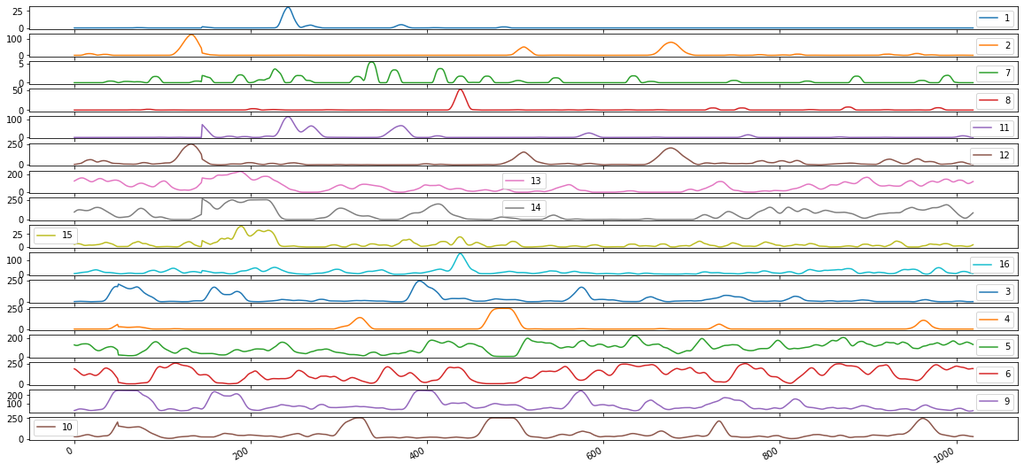

```python
sop_1_shift.plot(subplots=True, figsize=(20,10));
```

###### Сдвиг для SOP2

```python
sop_2_shift=pd.DataFrame()
```

```python
for col in sop_2_normal[hord].columns:
    sop_2_shift[col]=np.roll(sop_2_normal[col], shift=145)
for col in sop_2_normal[rs].columns:
    sop_2_shift[col]=np.roll(sop_2_normal[col], shift=50)
```

##### Визуализируем выделенные признаки для SOP2

```python
sop_2_shift.head()
```

|  | 1 | 2 | 7 | 8 | 11 | 12 | 13 | 14 | 15 | 16 | 3 | 4 | 5 | 6 | 9 | 10 |
| --- | --- | --- | --- | --- | --- | --- | --- | --- | --- | --- | --- | --- | --- | --- | --- | --- |
| 0 | 0.173678 | 7.975283 | 0.115785 | 0.0 | 0.0 | 59.879852 | 119.654705 | 36.815865 | 2.387820 | 27.130462 | 0.0 | 0.231570 | 38.977903 | 2.695078 | 16.720601 | 7.168075 |
| 1 | 0.212592 | 6.462393 | 0.083287 | 0.0 | 0.0 | 54.912511 | 123.416964 | 39.068917 | 2.127517 | 29.374856 | 0.0 | 0.283456 | 38.047663 | 1.893926 | 16.934478 | 7.623769 |
| 2 | 0.238813 | 4.716928 | 0.049014 | 0.0 | 0.0 | 49.517353 | 128.299366 | 41.124789 | 1.867169 | 31.166178 | 0.0 | 0.318417 | 38.388943 | 1.371223 | 17.071880 | 7.914690 |
| 3 | 0.253078 | 3.078794 | 0.020086 | 0.0 | 0.0 | 44.730458 | 133.572052 | 42.889769 | 1.923869 | 32.376455 | 0.0 | 0.337437 | 39.653195 | 1.344043 | 17.043790 | 8.462922 |
| 4 | 0.258474 | 1.955934 | 0.003440 | 0.0 | 0.0 | 41.533035 | 138.621366 | 44.327814 | 2.374345 | 32.937225 | 0.0 | 0.344631 | 41.042655 | 1.851428 | 16.693594 | 9.331708 |

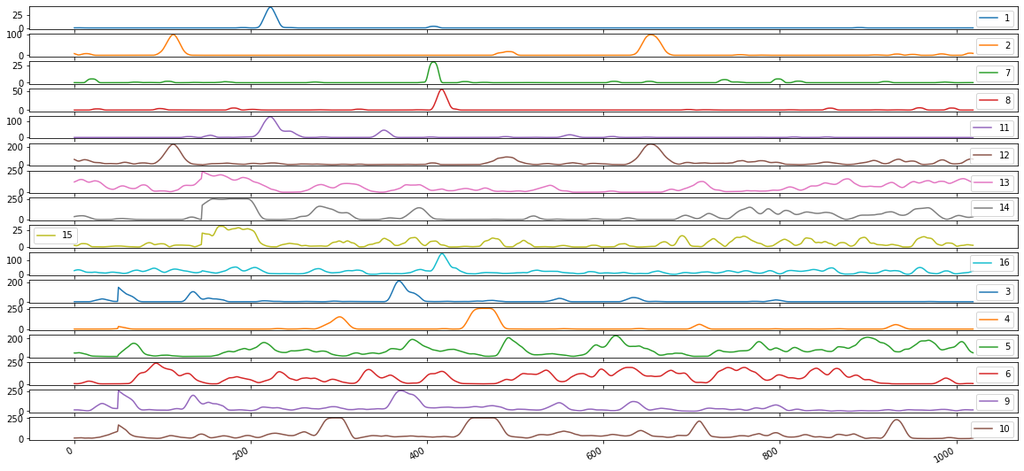

```python
sop_2_shift.plot(subplots=True, figsize=(20,10));
```

##### Сдвиг для SOP3

```python
sop_3_shift=pd.DataFrame()
```

```python
for col in sop_3_normal[hord].columns:
    sop_3_shift[col]=np.roll(sop_3_normal[col], shift=145)
for col in sop_3_normal[rs].columns:
    sop_3_shift[col]=np.roll(sop_3_normal[col], shift=50)
```

##### Визуализируем выделенные признаки для SOP3

```python
sop_3_shift.head()
```

|  | 1 | 2 | 7 | 8 | 11 | 12 | 13 | 14 | 15 | 16 | 3 | 4 | 5 | 6 | 9 | 10 |
| --- | --- | --- | --- | --- | --- | --- | --- | --- | --- | --- | --- | --- | --- | --- | --- | --- |
| 0 | 0.0 | 0.122536 | 0.0 | 1.182839 | 7.404269 | 30.809448 | 52.023251 | 195.452322 | 28.897099 | 3.626799 | 165.918163 | 0.524473 | 45.099665 | 7.870143 | 198.595064 | 51.630717 |
| 1 | 0.0 | 0.050214 | 0.0 | 1.293755 | 7.576996 | 30.488395 | 54.826251 | 200.960638 | 30.355580 | 4.520269 | 144.595801 | 0.374791 | 52.394378 | 7.904784 | 179.636838 | 49.248042 |
| 2 | 0.0 | 0.008600 | 0.0 | 1.353190 | 7.583413 | 29.559527 | 58.065228 | 205.995716 | 31.221304 | 5.771934 | 122.850025 | 0.242924 | 59.675415 | 8.167453 | 159.394341 | 47.446603 |
| 3 | 0.0 | 0.000000 | 0.0 | 1.378525 | 7.411980 | 27.807475 | 61.920310 | 210.609430 | 31.418321 | 7.390300 | 101.128927 | 0.243302 | 66.867080 | 8.825758 | 138.456689 | 46.728922 |
| 4 | 0.0 | 0.000000 | 0.0 | 1.382669 | 7.021435 | 25.220531 | 66.452320 | 214.835052 | 30.995800 | 9.278848 | 79.967764 | 0.464631 | 73.645683 | 9.973766 | 117.489818 | 47.475062 |

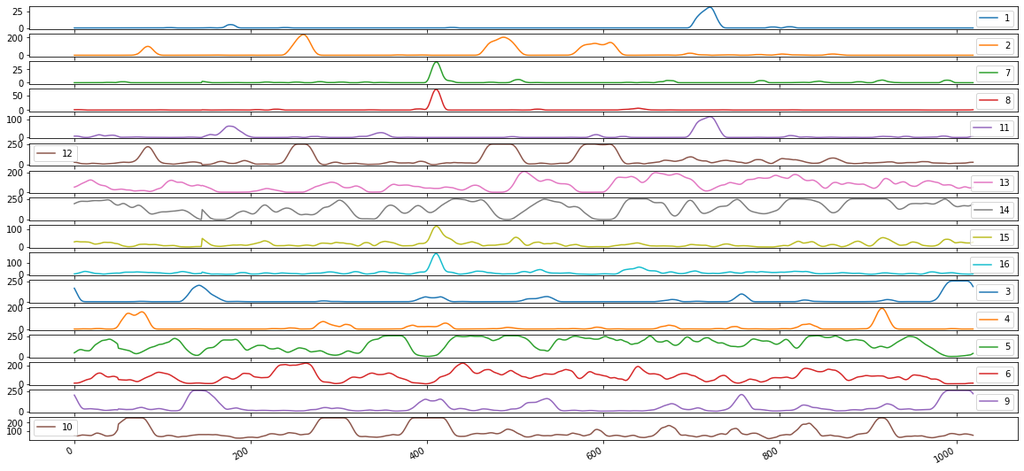

```python
sop_3_shift.plot(subplots=True, figsize=(20,10));
```

### Теневой и эхо-контактный метод

#### Выделим признаки теневого и эхо-контактного метода

```python
echo = [1, 2, 3, 4, 7, 8]
shadow = [5, 6, 13, 14]
echo_cont = [9, 10, 11, 12, 15, 16]
```

##### SOP1

```python
sop_1_shift=sop_1_shift.T
```

```python
sop_1_shift
```

|  | 0 | 1 | 2 | 3 | 4 | 5 | 6 | 7 | 8 | 9 | 10 | 11 | 12 | 13 | 14 | 15 | 16 | 17 | 18 | 19 | 20 | 21 | 22 | 23 | 24 | 25 | 26 | 27 | 28 | … |
| --- | --- | --- | --- | --- | --- | --- | --- | --- | --- | --- | --- | --- | --- | --- | --- | --- | --- | --- | --- | --- | --- | --- | --- | --- | --- | --- | --- | --- | --- | --- |
| 1 | 0.000000 | 0.000000 | 0.000000 | 0.000000 | 0.000000 | 0.000000 | 0.000000 | 0.000000 | 0.000000 | 0.000000 | 0.000000 | 0.000000 | 0.000000 | 0.000000 | 0.000000 | 0.000000 | 0.000000 | 0.000000 | 0.000000 | 0.000000 | 0.000000 | 0.000000 | 0.000000 | 0.000000 | 0.000000 | 0.000000 | 0.000000 | 0.000000 | 0.000000 | … |
| 2 | 0.000000 | 0.000000 | 0.000000 | 0.000000 | 0.000000 | 0.000000 | 0.017199 | 0.148586 | 0.589909 | 1.530980 | 3.002043 | 4.789649 | 6.566073 | 8.063016 | 9.144333 | 9.804333 | 10.128597 | 10.224598 | 10.145438 | 9.852653 | 9.240075 | 8.214291 | 6.767273 | 5.022556 | 3.265266 | 1.901512 | 1.272591 | 1.458447 | 2.245954 | … |
| 7 | 0.000000 | 0.000000 | 0.000000 | 0.000000 | 0.000000 | 0.000000 | 0.000000 | 0.000000 | 0.000000 | 0.000000 | 0.000000 | 0.000000 | 0.000000 | 0.000000 | 0.000000 | 0.000000 | 0.000000 | 0.000000 | 0.000000 | 0.000000 | 0.000000 | 0.000000 | 0.000000 | 0.000000 | 0.000000 | 0.000000 | 0.000000 | 0.000000 | 0.000000 | … |
| 8 | 0.000000 | 0.000000 | 0.000000 | 0.000000 | 0.000000 | 0.000000 | 0.003440 | 0.020086 | 0.049014 | 0.083287 | 0.115785 | 0.141728 | 0.159209 | 0.168719 | 0.172316 | 0.172834 | 0.172316 | 0.168719 | 0.159209 | 0.141728 | 0.115785 | 0.083287 | 0.049014 | 0.020086 | 0.003440 | 0.000000 | 0.000000 | 0.000000 | 0.000000 | … |
| 11 | 0.077976 | 0.021806 | 0.003440 | 0.000000 | 0.000000 | 0.000000 | 0.000000 | 0.000000 | 0.000000 | 0.000000 | 0.000000 | 0.000000 | 0.000000 | 0.000000 | 0.000000 | 0.000000 | 0.000000 | 0.000000 | 0.000000 | 0.000000 | 0.000000 | 0.000000 | 0.000000 | 0.000000 | 0.000000 | 0.000000 | 0.000000 | 0.000000 | 0.000000 | … |
| 12 | 5.020797 | 5.999819 | 7.520810 | 9.177236 | 10.738326 | 12.305285 | 14.183200 | 16.777953 | 20.510401 | 25.609074 | 31.877483 | 38.626784 | 45.017567 | 50.429885 | 54.659634 | 57.828986 | 60.135291 | 61.697237 | 62.436504 | 62.007998 | 59.973109 | 56.169149 | 50.916535 | 45.042680 | 39.642044 | 35.769460 | 34.137686 | 34.880729 | 37.554766 | … |
| 13 | 124.304976 | 130.065897 | 135.741851 | 141.159872 | 146.166286 | 150.611829 | 154.305414 | 157.021966 | 158.511488 | 158.563511 | 157.074055 | 154.078596 | 149.849714 | 144.828505 | 139.398989 | 133.819251 | 128.290763 | 123.151783 | 118.982606 | 116.467372 | 116.130675 | 118.103311 | 122.037393 | 127.260409 | 133.061398 | 138.809385 | 143.957181 | 148.046085 | 150.734835 | … |
| 14 | 95.959649 | 104.978504 | 112.718256 | 118.749691 | 122.840640 | 125.003872 | 125.480261 | 124.644653 | 122.964161 | 120.913058 | 118.867762 | 117.093224 | 115.726301 | 114.856949 | 114.629919 | 115.261470 | 116.958919 | 119.894579 | 124.080188 | 129.344470 | 135.250195 | 141.139340 | 146.412798 | 150.630394 | 153.590000 | 155.247294 | 155.695227 | 155.093014 | 153.512505 | … |
| 15 | 5.045420 | 5.646539 | 6.058988 | 6.291080 | 6.350695 | 6.263033 | 6.061634 | 5.720497 | 5.215917 | 4.537694 | 3.800834 | 3.283968 | 3.039691 | 3.016464 | 3.201312 | 3.514803 | 3.700693 | 3.710725 | 3.619986 | 3.533206 | 3.538419 | 3.586927 | 3.691830 | 3.866379 | 4.057687 | 4.216981 | 4.362113 | 4.554246 | 4.867323 | … |
| 16 | 5.602657 | 6.193373 | 6.982821 | 7.831892 | 8.730952 | 9.731136 | 10.849840 | 12.025544 | 13.124970 | 13.990164 | 14.525572 | 14.800510 | 15.020337 | 15.469095 | 16.372381 | 17.813619 | 19.742492 | 21.885414 | 23.945899 | 25.795928 | 27.475902 | 29.046407 | 30.492010 | 31.678534 | 32.371999 | 32.307840 | 31.396173 | 29.767066 | 27.682979 | … |
| 3 | 1.515650 | 2.031938 | 2.670156 | 3.326473 | 3.900888 | 4.313397 | 4.524148 | 4.537377 | 4.392209 | 4.143227 | 3.827974 | 3.460759 | 3.048981 | 2.579476 | 2.007446 | 1.361753 | 0.749042 | 0.296276 | 0.069410 | 0.006880 | 0.032678 | 0.213173 | 0.596195 | 1.109819 | 1.641323 | 2.099019 | 2.433715 | 2.637685 | 2.733671 | … |
| 4 | 0.000000 | 0.000000 | 0.000000 | 0.000000 | 0.003440 | 0.020086 | 0.049014 | 0.083287 | 0.115785 | 0.141728 | 0.159209 | 0.168719 | 0.172316 | 0.172834 | 0.172316 | 0.168719 | 0.159209 | 0.141728 | 0.115785 | 0.083287 | 0.049014 | 0.020086 | 0.003440 | 0.000000 | 0.000000 | 0.000000 | 0.000000 | 0.000000 | 0.000000 | … |
| 5 | 125.949472 | 122.390928 | 120.355889 | 119.999240 | 121.339051 | 124.246383 | 128.094340 | 131.864978 | 134.645872 | 136.219737 | 137.002422 | 137.475681 | 137.834740 | 138.030195 | 137.732094 | 136.439017 | 133.745618 | 129.509856 | 123.750142 | 116.522012 | 107.987097 | 98.653883 | 89.446365 | 81.242397 | 74.443973 | 69.104480 | 65.304747 | 63.323206 | 63.301264 | … |
| 6 | 183.870704 | 178.840439 | 171.816888 | 163.261959 | 153.874832 | 144.298812 | 134.995145 | 126.211356 | 118.165981 | 111.360493 | 106.704607 | 104.983415 | 106.191043 | 109.591629 | 114.013717 | 118.353196 | 121.760988 | 123.660316 | 123.569160 | 121.241119 | 117.015599 | 111.862299 | 107.078472 | 103.857733 | 102.988712 | 104.688903 | 108.819026 | 115.066608 | 123.196926 | … |
| 9 | 23.821041 | 26.908326 | 30.676958 | 34.652803 | 38.212631 | 40.924998 | 42.496641 | 42.838689 | 42.187871 | 40.967496 | 39.539649 | 38.067389 | 36.524337 | 34.676509 | 32.329316 | 29.632069 | 27.099130 | 25.232768 | 24.236966 | 23.973107 | 24.247178 | 25.060186 | 26.415560 | 28.092398 | 29.752085 | 31.186860 | 32.455793 | 33.601058 | 34.505940 | … |
| 10 | 25.080305 | 24.245062 | 23.786591 | 24.009460 | 24.975102 | 26.641636 | 28.813143 | 31.160625 | 33.676723 | 36.450802 | 39.428887 | 42.404846 | 45.145057 | 47.430570 | 49.111247 | 49.867772 | 49.369484 | 47.424828 | 44.208180 | 40.375867 | 36.677365 | 33.510371 | 30.901075 | 28.779865 | 26.958254 | 25.429562 | 24.516469 | 24.494411 | 25.512394 | … |

16 rows × 1020 columns

```python
shadow_features_sop1=sop_1_shift.loc[shadow].T
```

```python
shadow_features_sop1.head()
```

|  | 5 | 6 | 13 | 14 |
| --- | --- | --- | --- | --- |
| 0 | 125.949472 | 183.870704 | 124.304976 | 95.959649 |
| 1 | 122.390928 | 178.840439 | 130.065897 | 104.978504 |
| 2 | 120.355889 | 171.816888 | 135.741851 | 112.718256 |
| 3 | 119.999240 | 163.261959 | 141.159872 | 118.749691 |
| 4 | 121.339051 | 153.874832 | 146.166286 | 122.840640 |

```python
echo_cont_features_sop1=sop_1_shift.loc[echo_cont].T
```

```python
echo_cont_features_sop1.head()
```

|  | 9 | 10 | 11 | 12 | 15 | 16 |
| --- | --- | --- | --- | --- | --- | --- |
| 0 | 23.821041 | 25.080305 | 0.077976 | 5.020797 | 5.045420 | 5.602657 |
| 1 | 26.908326 | 24.245062 | 0.021806 | 5.999819 | 5.646539 | 6.193373 |
| 2 | 30.676958 | 23.786591 | 0.003440 | 7.520810 | 6.058988 | 6.982821 |
| 3 | 34.652803 | 24.009460 | 0.000000 | 9.177236 | 6.291080 | 7.831892 |
| 4 | 38.212631 | 24.975102 | 0.000000 | 10.738326 | 6.350695 | 8.730952 |

##### SOP2

```python
sop_2_shift=sop_2_shift.T
```

```python
sop_2_shift
```

|  | 0 | 1 | 2 | 3 | 4 | 5 | 6 | 7 | 8 | 9 | 10 | 11 | 12 | 13 | 14 | 15 | 16 | 17 | 18 | 19 | 20 | 21 | 22 | 23 | 24 | 25 | 26 | 27 | 28 | … |
| --- | --- | --- | --- | --- | --- | --- | --- | --- | --- | --- | --- | --- | --- | --- | --- | --- | --- | --- | --- | --- | --- | --- | --- | --- | --- | --- | --- | --- | --- | --- |
| 1 | 0.173678 | 0.212592 | 0.238813 | 0.253078 | 0.258474 | 0.259250 | 0.258474 | 0.253078 | 0.238813 | 0.212592 | 0.173678 | 0.124930 | 0.073522 | 0.030129 | 0.005160 | 0.000000 | 0.000000 | 0.000000 | 0.000000 | 0.000000 | 0.000000 | 0.000000 | 0.000000 | 0.000000 | 0.000000 | 0.000000 | 0.000000 | 0.000000 | 0.000000 | … |
| 2 | 7.975283 | 6.462393 | 4.716928 | 3.078794 | 1.955934 | 1.630275 | 2.107444 | 3.160360 | 4.455053 | 5.695307 | 6.707868 | 7.425598 | 7.862220 | 8.065931 | 8.075822 | 7.896152 | 7.495249 | 6.823043 | 5.856070 | 4.647436 | 3.338717 | 2.122057 | 1.148928 | 0.493072 | 0.143150 | 0.018919 | 0.000000 | 0.000000 | 0.000000 | … |
| 7 | 0.115785 | 0.083287 | 0.049014 | 0.020086 | 0.003440 | 0.000000 | 0.000000 | 0.000000 | 0.000000 | 0.000000 | 0.000000 | 0.108354 | 0.632701 | 1.543956 | 2.623536 | 3.647229 | 4.464434 | 5.015075 | 5.314641 | 5.427944 | 5.444260 | 5.427944 | 5.314641 | 5.015075 | 4.464434 | 3.647229 | 2.623536 | 1.543956 | 0.632701 | … |
| 8 | 0.000000 | 0.000000 | 0.000000 | 0.000000 | 0.000000 | 0.000000 | 0.000000 | 0.000000 | 0.000000 | 0.000000 | 0.000000 | 0.000000 | 0.000000 | 0.000000 | 0.000000 | 0.000000 | 0.000000 | 0.065357 | 0.381629 | 0.931275 | 1.582450 | 2.199916 | 2.692833 | 3.024966 | 3.205656 | 3.273998 | 3.283840 | 3.273998 | 3.205656 | … |
| 11 | 0.000000 | 0.000000 | 0.000000 | 0.000000 | 0.000000 | 0.000000 | 0.000000 | 0.000000 | 0.000000 | 0.000000 | 0.000000 | 0.000000 | 0.000000 | 0.000000 | 0.000000 | 0.000000 | 0.000000 | 0.000000 | 0.000000 | 0.000000 | 0.000000 | 0.000000 | 0.000000 | 0.000000 | 0.000000 | 0.000000 | 0.000000 | 0.000000 | 0.000000 | … |
| 12 | 59.879852 | 54.912511 | 49.517353 | 44.730458 | 41.533035 | 40.558592 | 41.771931 | 44.620711 | 48.290944 | 51.908858 | 54.739827 | 56.384369 | 56.776954 | 56.016777 | 54.293558 | 51.770847 | 48.608328 | 44.961189 | 40.961073 | 36.848385 | 32.993816 | 29.688283 | 27.126677 | 25.423818 | 24.500153 | 24.180307 | 24.173420 | 24.059611 | 23.473157 | … |
| 13 | 119.654705 | 123.416964 | 128.299366 | 133.572052 | 138.621366 | 142.953529 | 146.185647 | 148.063606 | 148.465618 | 147.349639 | 144.693652 | 140.554637 | 135.232582 | 129.402234 | 123.945331 | 119.714947 | 117.319863 | 117.020005 | 118.679975 | 121.706748 | 125.302580 | 128.659077 | 131.149140 | 132.422739 | 132.408502 | 131.202096 | 128.972919 | 125.813241 | 121.646058 | … |
| 14 | 36.815865 | 39.068917 | 41.124789 | 42.889769 | 44.327814 | 45.490886 | 46.425279 | 47.130411 | 47.577399 | 47.628253 | 47.062131 | 45.752811 | 43.698306 | 40.975720 | 37.740817 | 34.179638 | 30.441565 | 26.604680 | 22.695842 | 18.748526 | 14.858211 | 11.177964 | 7.899663 | 5.195734 | 3.143893 | 1.725287 | 0.847444 | 0.359507 | 0.115446 | … |
| 15 | 2.387820 | 2.127517 | 1.867169 | 1.923869 | 2.374345 | 3.101950 | 3.906113 | 4.536930 | 4.905746 | 5.043141 | 5.033140 | 4.974679 | 4.920891 | 4.817477 | 4.561224 | 4.089831 | 3.404903 | 2.552950 | 1.649167 | 0.876335 | 0.423106 | 0.327017 | 0.337437 | 0.344631 | 0.345667 | 0.344631 | 0.337437 | 0.318417 | 0.283456 | … |
| 16 | 27.130462 | 29.374856 | 31.166178 | 32.376455 | 32.937225 | 32.850578 | 32.142429 | 30.810896 | 28.856436 | 26.348592 | 23.495863 | 20.704087 | 18.368436 | 16.693128 | 15.667575 | 15.189909 | 14.974643 | 14.706842 | 14.401298 | 14.274744 | 14.514157 | 15.120734 | 15.827660 | 16.288781 | 16.218870 | 15.536050 | 14.464406 | 13.394441 | 12.584767 | … |
| 3 | 0.000000 | 0.000000 | 0.000000 | 0.000000 | 0.000000 | 0.000000 | 0.000000 | 0.000000 | 0.000000 | 0.000000 | 0.000000 | 0.000000 | 0.000000 | 0.000000 | 0.000000 | 0.010319 | 0.099815 | 0.436506 | 1.232381 | 2.645367 | 4.650104 | 7.084918 | 9.707576 | 12.279869 | 14.641427 | 16.774628 | 18.827107 | 21.013723 | 23.457398 | … |
| 4 | 0.231570 | 0.283456 | 0.318417 | 0.337437 | 0.344631 | 0.345667 | 0.344631 | 0.337437 | 0.318417 | 0.283456 | 0.231570 | 0.166574 | 0.098029 | 0.040171 | 0.006880 | 0.000000 | 0.000000 | 0.000000 | 0.000000 | 0.000000 | 0.000000 | 0.000000 | 0.000000 | 0.000000 | 0.000000 | 0.000000 | 0.000000 | 0.000000 | 0.000000 | … |
| 5 | 38.977903 | 38.047663 | 38.388943 | 39.653195 | 41.042655 | 41.789087 | 41.454260 | 39.975189 | 37.653184 | 35.027572 | 32.580440 | 30.473548 | 28.542071 | 26.431717 | 23.802373 | 20.533233 | 16.782601 | 12.929415 | 9.440828 | 6.689728 | 4.810443 | 3.699494 | 3.118388 | 2.829326 | 2.670436 | 2.572028 | 2.521055 | 2.497594 | 2.463767 | … |
| 6 | 2.695078 | 1.893926 | 1.371223 | 1.344043 | 1.851428 | 2.806213 | 4.162990 | 5.982405 | 8.343942 | 11.247439 | 14.631899 | 18.359760 | 22.168694 | 25.693637 | 28.586543 | 30.593841 | 31.589699 | 31.579502 | 30.666488 | 28.992945 | 26.648520 | 23.668520 | 20.152032 | 16.323896 | 12.490707 | 8.930385 | 5.861601 | 3.444450 | 1.763534 | … |
| 9 | 16.720601 | 16.934478 | 17.071880 | 17.043790 | 16.693594 | 16.001968 | 15.008992 | 13.777167 | 12.361918 | 10.851098 | 9.347838 | 7.945912 | 6.705993 | 5.673865 | 4.945399 | 4.764326 | 5.460086 | 7.391736 | 10.871210 | 16.032172 | 22.659847 | 30.330120 | 38.515904 | 46.705606 | 54.540630 | 61.923374 | 68.972580 | 75.871610 | 82.638857 | … |
| 10 | 7.168075 | 7.623769 | 7.914690 | 8.462922 | 9.331708 | 10.223989 | 10.809151 | 10.850935 | 10.260306 | 9.127181 | 7.720229 | 6.519352 | 6.122678 | 6.503185 | 7.014598 | 7.284054 | 7.183605 | 6.741107 | 6.102406 | 5.579768 | 5.636537 | 6.505715 | 7.802714 | 9.217468 | 10.595393 | 11.802008 | 12.867505 | 14.068542 | 15.753681 | … |

16 rows × 1020 columns

```python
shadow_features_sop2=sop_2_shift.loc[shadow].T
```

```python
shadow_features_sop2
```

|  | 5 | 6 | 13 | 14 |
| --- | --- | --- | --- | --- |
| 0 | 38.977903 | 2.695078 | 119.654705 | 36.815865 |
| 1 | 38.047663 | 1.893926 | 123.416964 | 39.068917 |
| 2 | 38.388943 | 1.371223 | 128.299366 | 41.124789 |
| 3 | 39.653195 | 1.344043 | 133.572052 | 42.889769 |
| 4 | 41.042655 | 1.851428 | 138.621366 | 44.327814 |
| ... | ... | ... | ... | ... |
| 1015 | 65.897380 | 4.894336 | 129.345628 | 27.994548 |
| 1016 | 56.544570 | 4.799997 | 124.360181 | 28.912180 |
| 1017 | 49.559055 | 4.568784 | 120.344003 | 30.390955 |
| 1018 | 44.589566 | 4.144125 | 117.959357 | 32.303457 |
| 1019 | 41.159330 | 3.503326 | 117.704473 | 34.498667 |

1020 rows × 4 columns

```python
echo_features_sop2=sop_2_shift.loc[echo].T
```

```python
echo_features_sop2
```

|  | 1 | 2 | 3 | 4 | 7 | 8 |
| --- | --- | --- | --- | --- | --- | --- |
| 0 | 0.173678 | 7.975283 | 0.0 | 0.231570 | 0.115785 | 0.0 |
| 1 | 0.212592 | 6.462393 | 0.0 | 0.283456 | 0.083287 | 0.0 |
| 2 | 0.238813 | 4.716928 | 0.0 | 0.318417 | 0.049014 | 0.0 |
| 3 | 0.253078 | 3.078794 | 0.0 | 0.337437 | 0.020086 | 0.0 |
| 4 | 0.258474 | 1.955934 | 0.0 | 0.344631 | 0.003440 | 0.0 |
| ... | ... | ... | ... | ... | ... | ... |
| 1015 | 0.000000 | 10.225423 | 0.0 | 0.000000 | 0.172834 | 0.0 |
| 1016 | 0.005160 | 10.287239 | 0.0 | 0.006880 | 0.172316 | 0.0 |
| 1017 | 0.030129 | 10.161162 | 0.0 | 0.040171 | 0.168719 | 0.0 |
| 1018 | 0.073522 | 9.796566 | 0.0 | 0.098029 | 0.159209 | 0.0 |
| 1019 | 0.124930 | 9.092852 | 0.0 | 0.166574 | 0.141728 | 0.0 |

1020 rows × 6 columns

```python
echo_cont_features_sop2=sop_2_shift.loc[echo_cont].T
```

```python
echo_cont_features_sop2
```

|  | 9 | 10 | 11 | 12 | 15 | 16 |
| --- | --- | --- | --- | --- | --- | --- |
| 0 | 16.720601 | 7.168075 | 0.0 | 59.879852 | 2.387820 | 27.130462 |
| 1 | 16.934478 | 7.623769 | 0.0 | 54.912511 | 2.127517 | 29.374856 |
| 2 | 17.071880 | 7.914690 | 0.0 | 49.517353 | 1.867169 | 31.166178 |
| 3 | 17.043790 | 8.462922 | 0.0 | 44.730458 | 1.923869 | 32.376455 |
| 4 | 16.693594 | 9.331708 | 0.0 | 41.533035 | 2.374345 | 32.937225 |
| ... | ... | ... | ... | ... | ... | ... |
| 1015 | 16.768817 | 0.893815 | 0.0 | 63.034158 | 3.111703 | 15.826810 |
| 1016 | 16.244679 | 2.181145 | 0.0 | 65.103968 | 2.876836 | 17.705681 |
| 1017 | 16.013418 | 3.709705 | 0.0 | 66.117919 | 2.688996 | 19.819805 |
| 1018 | 16.129970 | 5.172520 | 0.0 | 65.718670 | 2.582949 | 22.160487 |
| 1019 | 16.434418 | 6.355914 | 0.0 | 63.623379 | 2.527413 | 24.653829 |

1020 rows × 6 columns

##### SOP3

```python
sop_3_shift=sop_3_shift.T
```

```python
sop_3_shift
```

|  | 0 | 1 | 2 | 3 | 4 | 5 | 6 | 7 | 8 | 9 | 10 | 11 | 12 | 13 | 14 | 15 | 16 | 17 | 18 | 19 | 20 | 21 | 22 | 23 | 24 | 25 | 26 | 27 | 28 | … |
| --- | --- | --- | --- | --- | --- | --- | --- | --- | --- | --- | --- | --- | --- | --- | --- | --- | --- | --- | --- | --- | --- | --- | --- | --- | --- | --- | --- | --- | --- | --- |
| 1 | 0.000000 | 0.000000 | 0.000000 | 0.000000 | 0.000000 | 0.000000 | 0.000000 | 0.000000 | 0.000000 | 0.000000 | 0.000000 | 0.000000 | 0.000000 | 0.000000 | 0.000000 | 0.000000 | 0.000000 | 0.000000 | 0.000000 | 0.000000 | 0.000000 | 0.000000 | 0.000000 | 0.000000 | 0.000000 | 0.000000 | 0.000000 | 0.000000 | 0.000000 | … |
| 2 | 0.122536 | 0.050214 | 0.008600 | 0.000000 | 0.000000 | 0.000000 | 0.000000 | 0.000000 | 0.000000 | 0.000000 | 0.000000 | 0.000000 | 0.000000 | 0.000000 | 0.000000 | 0.003440 | 0.020086 | 0.049014 | 0.083287 | 0.115785 | 0.141728 | 0.159209 | 0.168719 | 0.172316 | 0.172834 | 0.172316 | 0.168719 | 0.159209 | 0.141728 | … |
| 7 | 0.000000 | 0.000000 | 0.000000 | 0.000000 | 0.000000 | 0.003440 | 0.020086 | 0.049014 | 0.083287 | 0.115785 | 0.141728 | 0.159209 | 0.168719 | 0.172316 | 0.172834 | 0.172316 | 0.168719 | 0.159209 | 0.141728 | 0.115785 | 0.083287 | 0.049014 | 0.020086 | 0.003440 | 0.000000 | 0.000000 | 0.000000 | 0.000000 | 0.000000 | … |
| 8 | 1.182839 | 1.293755 | 1.353190 | 1.378525 | 1.382669 | 1.378525 | 1.349750 | 1.273670 | 1.133825 | 0.926280 | 0.666295 | 0.392116 | 0.160686 | 0.027519 | 0.000000 | 0.000000 | 0.000000 | 0.000000 | 0.000000 | 0.000000 | 0.000000 | 0.000000 | 0.000000 | 0.000000 | 0.000000 | 0.000000 | 0.000000 | 0.000000 | 0.000000 | … |
| 11 | 7.404269 | 7.576996 | 7.583413 | 7.411980 | 7.021435 | 6.360097 | 5.408192 | 4.224181 | 2.957410 | 1.813717 | 0.955388 | 0.407050 | 0.117904 | 0.015479 | 0.013759 | 0.113021 | 0.426430 | 1.065889 | 2.058171 | 3.337569 | 4.792399 | 6.307750 | 7.785292 | 9.210234 | 10.715434 | 12.216642 | 13.514916 | 14.415163 | 14.781524 | … |
| 12 | 30.809448 | 30.488395 | 29.559527 | 27.807475 | 25.220531 | 22.066384 | 18.877830 | 16.214074 | 14.401726 | 13.362052 | 12.749093 | 12.268255 | 11.745875 | 11.221206 | 10.972535 | 11.296975 | 12.308760 | 13.850617 | 15.553816 | 17.025566 | 17.966863 | 18.202755 | 17.753213 | 16.882988 | 16.021575 | 15.461779 | 15.135722 | 14.716270 | 13.920305 | … |
| 13 | 52.023251 | 54.826251 | 58.065228 | 61.920310 | 66.452320 | 71.522098 | 76.758206 | 81.711188 | 86.125425 | 90.049231 | 93.772985 | 97.668489 | 101.950899 | 106.587468 | 111.348279 | 115.932876 | 120.015753 | 123.163540 | 124.809776 | 124.477077 | 122.028441 | 117.749847 | 112.225291 | 106.107259 | 99.945834 | 94.099640 | 88.733141 | 83.862823 | 79.500642 | … |
| 14 | 195.452322 | 200.960638 | 205.995716 | 210.609430 | 214.835052 | 218.601020 | 221.704424 | 223.887876 | 225.022633 | 225.235863 | 224.809190 | 224.048444 | 223.310321 | 222.897318 | 223.016733 | 223.720597 | 224.887202 | 226.310285 | 227.827810 | 229.332845 | 230.762999 | 232.064358 | 233.130357 | 233.806335 | 233.958437 | 233.608565 | 233.008679 | 232.538301 | 232.458916 | … |
| 15 | 28.897099 | 30.355580 | 31.221304 | 31.418321 | 30.995800 | 30.192134 | 29.431177 | 29.055888 | 29.155194 | 29.401343 | 29.556079 | 29.446751 | 29.122611 | 28.823874 | 28.608573 | 28.394287 | 27.875444 | 26.997517 | 25.722857 | 23.995343 | 21.856960 | 19.638273 | 17.820425 | 16.719503 | 16.394196 | 16.684941 | 17.308628 | 18.073080 | 18.922770 | … |
| 16 | 3.626799 | 4.520269 | 5.771934 | 7.390300 | 9.278848 | 11.400811 | 13.724724 | 16.238809 | 18.889477 | 21.466367 | 23.646446 | 25.080265 | 25.633571 | 25.353317 | 24.449709 | 23.141607 | 21.617823 | 19.992690 | 18.231790 | 16.323971 | 14.300460 | 12.248516 | 10.356045 | 8.884031 | 7.921056 | 7.400056 | 7.063324 | 6.612059 | 5.926314 | … |
| 3 | 165.918163 | 144.595801 | 122.850025 | 101.128927 | 79.967764 | 60.063108 | 42.269196 | 27.441728 | 16.188650 | 8.615918 | 4.185609 | 1.914493 | 0.940155 | 0.644226 | 0.604400 | 0.603623 | 0.594113 | 0.566741 | 0.513529 | 0.431191 | 0.324002 | 0.205823 | 0.099229 | 0.028685 | 0.003440 | 0.000000 | 0.000000 | 0.000000 | 0.000000 | … |
| 4 | 0.524473 | 0.374791 | 0.242924 | 0.243302 | 0.464631 | 0.859959 | 1.293967 | 1.673835 | 1.956089 | 2.131529 | 2.216724 | 2.243471 | 2.243471 | 2.216724 | 2.133248 | 1.966132 | 1.706942 | 1.406464 | 1.198740 | 1.265622 | 1.700020 | 2.440713 | 3.272084 | 3.983295 | 4.491250 | 4.795421 | 4.937562 | 4.969574 | 4.917907 | … |
| 5 | 45.099665 | 52.394378 | 59.675415 | 66.867080 | 73.645683 | 79.365180 | 83.341019 | 85.123964 | 84.619496 | 82.208881 | 78.811124 | 75.514951 | 73.023061 | 71.404698 | 70.307036 | 69.511295 | 69.509382 | 71.508803 | 76.777623 | 85.761080 | 97.703491 | 111.030155 | 124.029953 | 135.423693 | 144.729797 | 152.260104 | 158.836026 | 165.415897 | 172.537067 | … |
| 6 | 7.870143 | 7.904784 | 8.167453 | 8.825758 | 9.973766 | 11.672329 | 14.031733 | 17.114346 | 20.756744 | 24.673235 | 28.672488 | 32.737552 | 36.897243 | 40.947841 | 44.444781 | 47.133518 | 49.241244 | 51.382876 | 54.373104 | 58.932632 | 65.383754 | 73.472515 | 82.397935 | 91.160637 | 99.048880 | 105.685619 | 110.841816 | 114.387504 | 116.301806 | … |
| 9 | 198.595064 | 179.636838 | 159.394341 | 138.456689 | 117.489818 | 97.224198 | 78.438403 | 61.945733 | 48.536918 | 38.693710 | 32.431012 | 29.216517 | 28.155602 | 28.358557 | 29.187184 | 30.156293 | 31.026008 | 31.682374 | 31.915033 | 31.501052 | 30.433462 | 29.044715 | 27.924557 | 27.192391 | 26.683736 | 26.177740 | 25.473676 | 24.371404 | 22.821308 | … |
| 10 | 51.630717 | 49.248042 | 47.446603 | 46.728922 | 47.475062 | 49.460012 | 51.981228 | 54.477096 | 56.459173 | 57.474181 | 57.391287 | 56.526216 | 55.530007 | 54.736498 | 54.111211 | 53.512596 | 52.718155 | 51.735041 | 51.086614 | 51.668494 | 54.160216 | 58.655639 | 64.367581 | 70.149992 | 75.001584 | 78.145560 | 79.205531 | 78.357259 | 76.106368 | … |

16 rows × 1020 columns

```python
shadow_features_sop3=sop_3_shift.loc[shadow].T
```

```python
shadow_features_sop3
```

|  | 5 | 6 | 13 | 14 |
| --- | --- | --- | --- | --- |
| 0 | 45.099665 | 7.870143 | 52.023251 | 195.452322 |
| 1 | 52.394378 | 7.904784 | 54.826251 | 200.960638 |
| 2 | 59.675415 | 8.167453 | 58.065228 | 205.995716 |
| 3 | 66.867080 | 8.825758 | 61.920310 | 210.609430 |
| 4 | 73.645683 | 9.973766 | 66.452320 | 214.835052 |
| ... | ... | ... | ... | ... |
| 1015 | 17.480603 | 7.345702 | 43.906807 | 169.588430 |
| 1016 | 20.344443 | 7.644998 | 43.816519 | 172.999450 |
| 1017 | 24.899393 | 7.778950 | 45.022854 | 177.767516 |
| 1018 | 30.938898 | 7.856551 | 47.055190 | 183.463880 |
| 1019 | 37.856674 | 7.886046 | 49.456391 | 189.525913 |

1020 rows × 4 columns

```python
echo_features_sop3=sop_3_shift.loc[echo].T
```

```python
echo_features_sop3
```

|  | 1 | 2 | 3 | 4 | 7 | 8 |
| --- | --- | --- | --- | --- | --- | --- |
| 0 | 0.0 | 0.122536 | 165.918163 | 0.524473 | 0.0 | 1.182839 |
| 1 | 0.0 | 0.050214 | 144.595801 | 0.374791 | 0.0 | 1.293755 |
| 2 | 0.0 | 0.008600 | 122.850025 | 0.242924 | 0.0 | 1.353190 |
| 3 | 0.0 | 0.000000 | 101.128927 | 0.243302 | 0.0 | 1.378525 |
| 4 | 0.0 | 0.000000 | 79.967764 | 0.464631 | 0.0 | 1.382669 |
| ... | ... | ... | ... | ... | ... | ... |
| 1015 | 0.0 | 0.421797 | 244.218448 | 0.919480 | 0.0 | 0.196237 |
| 1016 | 0.0 | 0.398022 | 234.605379 | 0.891206 | 0.0 | 0.319895 |
| 1017 | 0.0 | 0.354320 | 221.427375 | 0.842521 | 0.0 | 0.533844 |
| 1018 | 0.0 | 0.289463 | 205.088199 | 0.765454 | 0.0 | 0.782080 |
| 1019 | 0.0 | 0.208217 | 186.314387 | 0.657862 | 0.0 | 1.009567 |

1020 rows × 6 columns

```python
echo_cont_features_sop3=sop_3_shift.loc[echo_cont].T
```

```python
echo_cont_features_sop3
```

|  | 9 | 10 | 11 | 12 | 15 | 16 |
| --- | --- | --- | --- | --- | --- | --- |
| 0 | 198.595064 | 51.630717 | 7.404269 | 30.809448 | 28.897099 | 3.626799 |
| 1 | 179.636838 | 49.248042 | 7.576996 | 30.488395 | 30.355580 | 4.520269 |
| 2 | 159.394341 | 47.446603 | 7.583413 | 29.559527 | 31.221304 | 5.771934 |
| 3 | 138.456689 | 46.728922 | 7.411980 | 27.807475 | 31.418321 | 7.390300 |
| 4 | 117.489818 | 47.475062 | 7.021435 | 25.220531 | 30.995800 | 9.278848 |
| ... | ... | ... | ... | ... | ... | ... |
| 1015 | 252.487849 | 64.238536 | 3.087885 | 29.313311 | 22.761012 | 1.709986 |
| 1016 | 248.299681 | 62.233794 | 4.337819 | 30.259344 | 23.074821 | 1.957926 |
| 1017 | 240.910577 | 59.846110 | 5.487349 | 30.650085 | 23.944623 | 2.260309 |
| 1018 | 229.927412 | 57.108653 | 6.402023 | 30.746988 | 25.339069 | 2.596341 |
| 1019 | 215.601959 | 54.309429 | 7.032385 | 30.810818 | 27.085105 | 3.020945 |

1020 rows × 6 columns

## 3.2. ВЫБОР И ПОСТРОЕНИЕ НОВЫХ ПЕРЕМЕННЫХ; ТЕСТИРОВАНИЕ ЗНАЧИМОСТИ ВЫБРАННЫХ ПЕРЕМЕННЫХ

### 3.2.1 Описание

Для получения новых переменных, которые в будущем пригодятся для обучения модели необходимо выделить из исходного набора данных статистические характеристики, которые явно указывают на тот или иной тип схемы контроля, реализованный в ПУЗК.

### 3.2.2 Функция для получения переменных

```python
features_train_sop_1=pd.DataFrame()
```

```python
features_train_sop_2=pd.DataFrame()
```

```python
features_train_sop_3=pd.DataFrame()
```

```python
def stats_add_to_data(data, new_data, name):
    new_data[name + "mean"]=data.mean(axis=1)
    new_data[name + "median"]=data.median(axis=1)
    new_data[name + "cum_sum"]=data.mean(axis=1).cumsum()
    new_data[name + "std"]=data.std(axis=1)
    new_data[name + "min"]=data.min(axis=1)
    new_data[name + "max"]=data.max(axis=1)
```

```python
stats_add_to_data(shadow_features_sop1, features_train_sop_1, "shadow_")
```

```python
stats_add_to_data(shadow_features_sop2, features_train_sop_2, "shadow_")
```

```python
stats_add_to_data(shadow_features_sop3, features_train_sop_3, "shadow_")
```

```python
stats_add_to_data(echo_features_sop1, features_train_sop_1, "echo_")
```

```python
stats_add_to_data(echo_features_sop2, features_train_sop_2, "echo_")
```

```python
stats_add_to_data(echo_features_sop3, features_train_sop_3, "echo_")
```

```python
stats_add_to_data(echo_cont_features_sop1, features_train_sop_1, "echo_cont_")
```

```python
stats_add_to_data(echo_cont_features_sop2, features_train_sop_2, "echo_cont_")
```

```python
stats_add_to_data(echo_cont_features_sop3, features_train_sop_3, "echo_cont_")
```

```python
features_train_sop_1.columns
```

```
Index(['shadow_mean', 'shadow_median', 'shadow_cum_sum', 'shadow_std',
       'shadow_min', 'shadow_max', 'echo_mean', 'echo_median', 'echo_cum_sum',
       'echo_std', 'echo_min', 'echo_max', 'echo_cont_mean',
       'echo_cont_median', 'echo_cont_cum_sum', 'echo_cont_std',
       'echo_cont_min', 'echo_cont_max'],
      dtype='object')
```

```python
features_train_sop_2.columns
```

```
Index(['shadow_mean', 'shadow_median', 'shadow_cum_sum', 'shadow_std',
       'shadow_min', 'shadow_max', 'echo_mean', 'echo_median', 'echo_cum_sum',
       'echo_std', 'echo_min', 'echo_max', 'echo_cont_mean',
       'echo_cont_median', 'echo_cont_cum_sum', 'echo_cont_std',
       'echo_cont_min', 'echo_cont_max'],
      dtype='object')
```

```python
features_train_sop_3.columns
```

```
Index(['shadow_mean', 'shadow_median', 'shadow_cum_sum', 'shadow_std',
       'shadow_min', 'shadow_max', 'echo_mean', 'echo_median', 'echo_cum_sum',
       'echo_std', 'echo_min', 'echo_max', 'echo_cont_mean',
       'echo_cont_median', 'echo_cont_cum_sum', 'echo_cont_std',
       'echo_cont_min', 'echo_cont_max'],
      dtype='object')
```

```python
features_train_sop_1.head()
```

|  | shadow_mean | shadow_median | shadow_cum_sum | shadow_std | shadow_min | shadow_max | echo_mean | echo_median | echo_cum_sum | echo_std | echo_min | echo_max | echo_cont_mean | echo_cont_median | echo_cont_cum_sum | echo_cont_std | echo_cont_min | echo_cont_max |
| --- | --- | --- | --- | --- | --- | --- | --- | --- | --- | --- | --- | --- | --- | --- | --- | --- | --- | --- |
| 0 | 132.521200 | 125.127224 | 132.521200 | 36.897211 | 95.959649 | 183.870704 | 0.252608 | 0.0 | 0.252608 | 0.618761 | 0.0 | 1.515650 | 10.774699 | 5.324039 | 10.774699 | 10.788506 | 0.077976 | 25.080305 |
| 1 | 134.068942 | 126.228412 | 266.590142 | 31.639327 | 104.978504 | 178.840439 | 0.338656 | 0.0 | 0.591265 | 0.829535 | 0.0 | 2.031938 | 11.502487 | 6.096596 | 22.277187 | 11.173874 | 0.021806 | 26.908326 |
| 2 | 135.158221 | 128.048870 | 401.748363 | 26.247918 | 112.718256 | 171.816888 | 0.445026 | 0.0 | 1.036291 | 1.090087 | 0.0 | 2.670156 | 12.504935 | 7.251815 | 34.782121 | 11.922005 | 0.003440 | 30.676958 |
| 3 | 135.792691 | 130.579556 | 537.541053 | 21.002097 | 118.749691 | 163.261959 | 0.554412 | 0.0 | 1.590703 | 1.358027 | 0.0 | 3.326473 | 13.660412 | 8.504564 | 48.442533 | 12.982817 | 0.000000 | 34.652803 |
| 4 | 136.055202 | 134.503463 | 673.596256 | 16.441441 | 121.339051 | 153.874832 | 0.650721 | 0.0 | 2.241424 | 1.592251 | 0.0 | 3.900888 | 14.834618 | 9.734639 | 63.277151 | 14.109841 | 0.000000 | 38.212631 |

```python
features_train_sop_2.head()
```

|  | shadow_mean | shadow_median | shadow_cum_sum | shadow_std | shadow_min | shadow_max | echo_mean | echo_median | echo_cum_sum | echo_std | echo_min | echo_max | echo_cont_mean | echo_cont_median | echo_cont_cum_sum | echo_cont_std | echo_cont_min | echo_cont_max |
| --- | --- | --- | --- | --- | --- | --- | --- | --- | --- | --- | --- | --- | --- | --- | --- | --- | --- | --- |
| 0 | 49.535888 | 37.896884 | 49.535888 | 49.611759 | 2.695078 | 119.654705 | 1.416053 | 0.144731 | 1.416053 | 3.214688 | 0.0 | 7.975283 | 18.881135 | 11.944338 | 18.881135 | 22.446989 | 0.0 | 59.879852 |
| 1 | 50.606868 | 38.558290 | 100.142755 | 51.527076 | 1.893926 | 123.416964 | 1.173621 | 0.147939 | 2.589674 | 2.593480 | 0.0 | 6.462393 | 18.495522 | 12.279124 | 37.376657 | 20.857540 | 0.0 | 54.912511 |
| 2 | 52.296080 | 39.756866 | 152.438836 | 53.814641 | 1.371223 | 128.299366 | 0.887196 | 0.143914 | 3.476870 | 1.880826 | 0.0 | 4.716928 | 17.922879 | 12.493285 | 55.299535 | 19.253567 | 0.0 | 49.517353 |
| 3 | 54.364765 | 41.271482 | 206.803600 | 56.074644 | 1.344043 | 133.572052 | 0.614899 | 0.136582 | 4.091769 | 1.215622 | 0.0 | 3.078794 | 17.422916 | 12.753356 | 72.722451 | 17.852249 | 0.0 | 44.730458 |
| 4 | 56.460816 | 42.685234 | 263.264416 | 58.073145 | 1.851428 | 138.621366 | 0.427080 | 0.130957 | 4.518849 | 0.763791 | 0.0 | 1.955934 | 17.144985 | 13.012651 | 89.867436 | 16.837727 | 0.0 | 41.533035 |

```python
features_train_sop_3.head()
```

|  | shadow_mean | shadow_median | shadow_cum_sum | shadow_std | shadow_min | shadow_max | echo_mean | echo_median | echo_cum_sum | echo_std | echo_min | echo_max | echo_cont_mean | echo_cont_median | echo_cont_cum_sum | echo_cont_std | echo_cont_min | echo_cont_max |
| --- | --- | --- | --- | --- | --- | --- | --- | --- | --- | --- | --- | --- | --- | --- | --- | --- | --- | --- |
| 0 | 75.111345 | 48.561458 | 75.111345 | 82.537044 | 7.870143 | 195.452322 | 27.958002 | 0.323504 | 27.958002 | 67.587908 | 0.0 | 165.918163 | 53.493899 | 29.853273 | 53.493899 | 73.196159 | 3.626799 | 198.595064 |
| 1 | 79.021513 | 53.610314 | 154.132858 | 84.105399 | 7.904784 | 200.960638 | 24.385760 | 0.212503 | 52.343762 | 58.892734 | 0.0 | 144.595801 | 50.304353 | 30.421988 | 103.798253 | 65.483498 | 4.520269 | 179.636838 |
| 2 | 82.975953 | 58.870321 | 237.108811 | 85.427617 | 8.167453 | 205.995716 | 20.742456 | 0.125762 | 73.086218 | 50.025037 | 0.0 | 122.850025 | 46.829520 | 30.390416 | 150.627773 | 57.339465 | 5.771934 | 159.394341 |
| 3 | 87.055644 | 64.393695 | 324.164455 | 86.457728 | 8.825758 | 210.609430 | 17.125126 | 0.121651 | 90.211344 | 41.156773 | 0.0 | 101.128927 | 43.202281 | 29.612898 | 193.830054 | 49.041095 | 7.390300 | 138.456689 |
| 4 | 91.226705 | 70.049002 | 415.391161 | 87.185484 | 9.973766 | 214.835052 | 13.635844 | 0.232315 | 103.847188 | 32.500319 | 0.0 | 79.967764 | 39.580249 | 28.108166 | 233.410303 | 40.964313 | 7.021435 | 117.489818 |

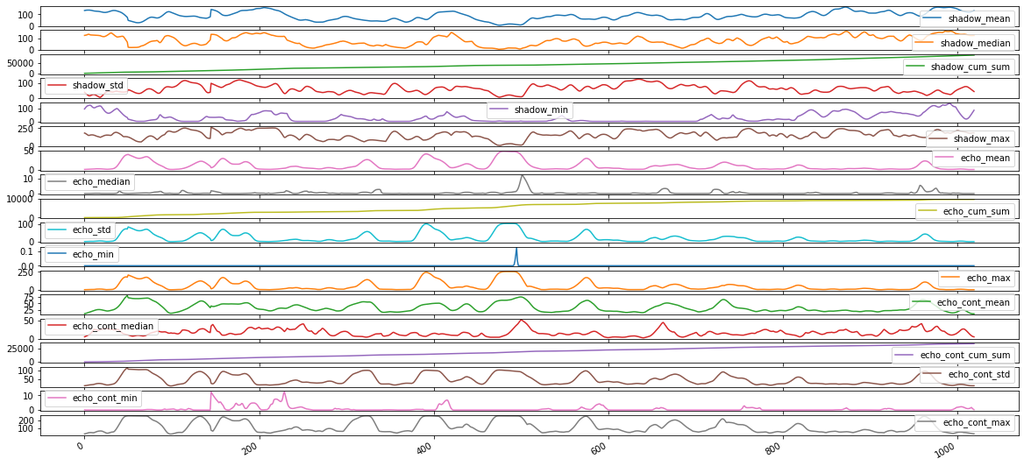

```python
features_train_sop_1.plot(subplots=True, figsize=(20,10));
```

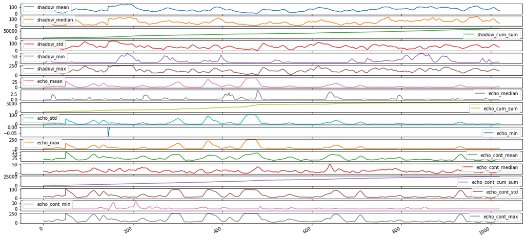

```python
features_train_sop_2.plot(subplots=True, figsize=(20,10));
```

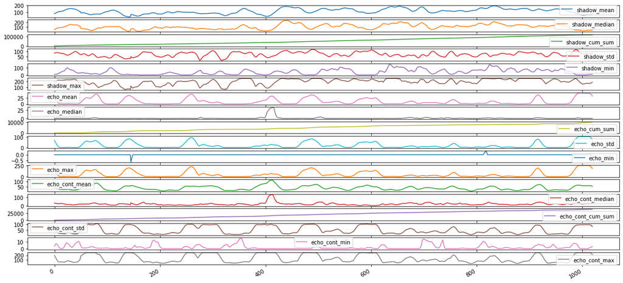

```python
features_train_sop_3.plot(subplots=True, figsize=(20,10));
```

было сформировано три новых массива, содержащих признаки для обучения алгоритма кластеризации.

#### Целевые переменные

```python
target_sop_1
```

|  | Начало дефекта | Длина дефекта | Высота дефекта | Тип дефекта | Сторона |
| --- | --- | --- | --- | --- | --- |
| 0 | 51 | 42.0 | 7 | L | A |
| 1 | 200 | 40.0 | 6 | L | B |
| 2 | 278 | 39.0 | 4 | L | A |
| 3 | 365 | 43.0 | 6 | L | B |
| 4 | 460 | 27.0 | 5 | L | A |
| 5 | 845 | 36.0 | 4 | L | B |
| 6 | 959 | 62.0 | 6 | L | A |
| 7 | 141 | NaN | 4 | T |  |

```python
target_sop_2
```

|  | Начало дефекта | Длина дефекта | Высота дефекта | Тип дефекта | Сторона |
| --- | --- | --- | --- | --- | --- |
| 0 | 178 | 37.0 | 6 | L | B |
| 1 | 258 | 38.0 | 4 | L | A |
| 2 | 337 | 53.0 | 5 | L | B |
| 3 | 822 | 37.0 | 5 | L | B |
| 4 | 957 | 48.0 | 5 | L | A |
| 5 | 123 | NaN | 3 | T |  |

```python
target_sop_3
```

|  | Начало дефекта | Длина дефекта | Высота дефекта | Тип дефекта | Сторона |
| --- | --- | --- | --- | --- | --- |
| 0 | 26 | 42.0 | 5 | L | A |
| 1 | 172 | 47.0 | 6 | L | B |
| 2 | 276 | 55.0 | 8 | L | B |
| 3 | 795 | 34.0 | 8 | L | B |
| 4 | 877 | 49.0 | 4 | L | A |
| 5 | 971 | 50.0 | 5 | L | B |
| 6 | 112 | NaN | 4 | T |  |

```python
target_values_sop_1=pd.DataFrame(index=features_train_sop_1.index)
```

```python
target_values_sop_2=pd.DataFrame(index=features_train_sop_2.index)
```

```python
target_values_sop_3=pd.DataFrame(index=features_train_sop_3.index)
```

```python
target_values_sop_1["target"]=0
target_values_sop_1["target"][51:51+42]=1
target_values_sop_1["target"][200:200+40]=1
target_values_sop_1["target"][278:278+39]=1
target_values_sop_1["target"][365:365+43]=1
target_values_sop_1["target"][460:460+27]=1
target_values_sop_1["target"][845:845+36]=1
target_values_sop_1["target"][959:959+62]=1
target_values_sop_1["target"][141:142]=1
```

```python
target_values_sop_2["target"]=0
target_values_sop_2["target"][178:178+37]=1
target_values_sop_2["target"][258:258+38]=1
target_values_sop_2["target"][337:337+53]=1
target_values_sop_2["target"][822:822+37]=1
target_values_sop_2["target"][957:957+48]=1
```

```python
target_values_sop_3["target"]=0
target_values_sop_3["target"][26:26+42]=1
target_values_sop_3["target"][172:172+47]=1
target_values_sop_3["target"][276:276+55]=1
target_values_sop_3["target"][795:795+34]=1
target_values_sop_3["target"][877:877+49]=1
```

##### Распределение целевой переменной

```python
target_values_sop_1["target"].value_counts()
```

```
0    731
1    289
Name: target, dtype: int64
```

```python
target_values_sop_2["target"].value_counts()
```

```
0    807
1    213
Name: target, dtype: int64
```

```python
target_values_sop_3["target"].value_counts()
```

```
0    793
1    227
Name: target, dtype: int64
```

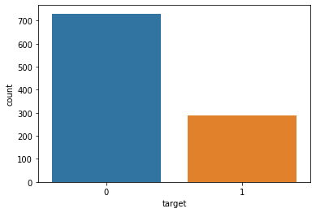

```python
sns.countplot(target_values_sop_1["target"])
```

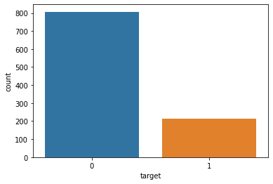

```python
sns.countplot(target_values_sop_2["target"])
```

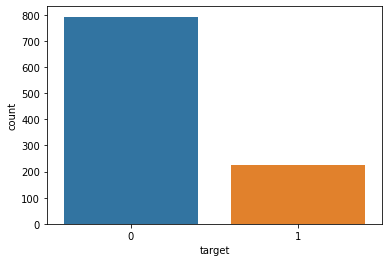

```python
sns.countplot(target_values_sop_3["target"])
```

### 3.2.3 Оценена значимости выбранных переменных

```python
from xgboost import XGBClassifier
from sklearn.model_selection import train_test_split
from xgboost import plot_importance
```

#### SOP1

```python
x_train, x_test,y_train, y_test = train_test_split(features_train_sop_1, target_values_sop_1,
                                                  stratify=target_values_sop_1, shuffle=True, random_state=20)
```

```python
xgb_cls= XGBClassifier(n_estimators=100, n_jobs=-1)
```

```python
xgb_cls.fit(x_train, y_train)
```

```
XGBClassifier(base_score=0.5, booster='gbtree', colsample_bylevel=1,
              colsample_bynode=1, colsample_bytree=1, gamma=0,
              learning_rate=0.1, max_delta_step=0, max_depth=3,
              min_child_weight=1, missing=None, n_estimators=100, n_jobs=-1,
              nthread=None, objective='binary:logistic', random_state=0,
              reg_alpha=0, reg_lambda=1, scale_pos_weight=1, seed=None,
              silent=None, subsample=1, verbosity=1)
```

```python
xgb_cls.feature_importances_
```

```
array([0.17767249, 0.04172469, 0.05721732, 0.1101867 , 0.06094225,
       0.09580161, 0.06819092, 0.04188598, 0.        , 0.02175009,
       0.        , 0.04504783, 0.02848469, 0.01736366, 0.        ,
       0.07960673, 0.13502774, 0.01909728], dtype=float32)
```

```python
xgb_cls.score(x_test, y_test)
```

```
0.984313725490196
```

#### Влияние признаков на целевую переменную

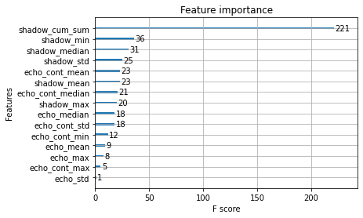

```python
plot_importance(xgb_cls)
```

Выберем первые 8 значимых признаков, так 9 и 10 имеют одинаковое значение, остальные имеют значимость менее 10% от значимости первого

```python
feature_choose_sop_1=features_train_sop_1[['shadow_cum_sum', 'shadow_min', 'shadow_median', 'shadow_std',
       'echo_cont_mean', 'shadow_mean' , 'echo_cont_median', 'shadow_max']]
```

Визуализируем выбранные переменные

```python
feature_choose_sop_1.head()
```

|  | shadow_cum_sum | shadow_min | shadow_median | shadow_std | echo_cont_mean | shadow_mean | echo_cont_median | shadow_max |
| --- | --- | --- | --- | --- | --- | --- | --- | --- |
| 0 | 132.521200 | 95.959649 | 125.127224 | 36.897211 | 10.774699 | 132.521200 | 5.324039 | 183.870704 |
| 1 | 266.590142 | 104.978504 | 126.228412 | 31.639327 | 11.502487 | 134.068942 | 6.096596 | 178.840439 |
| 2 | 401.748363 | 112.718256 | 128.048870 | 26.247918 | 12.504935 | 135.158221 | 7.251815 | 171.816888 |
| 3 | 537.541053 | 118.749691 | 130.579556 | 21.002097 | 13.660412 | 135.792691 | 8.504564 | 163.261959 |
| 4 | 673.596256 | 121.339051 | 134.503463 | 16.441441 | 14.834618 | 136.055202 | 9.734639 | 153.874832 |

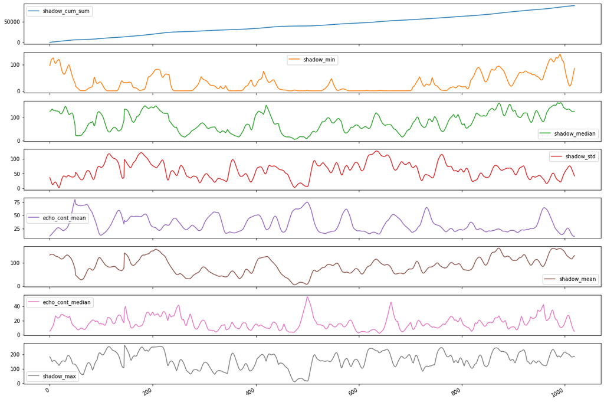

```python
feature_choose_sop_1.plot(subplots=True, figsize=(20,15));
```

#### SOP2

```python
x_train, x_test,y_train, y_test= train_test_split(features_train_sop_2, target_values_sop_2,
                                                  stratify=target_values_sop_2, shuffle=True, random_state=20)
```

```python
xgb_cls= XGBClassifier(n_estimators=100, n_jobs=-1)
```

```python
xgb_cls.fit(x_train, y_train)
```

```
XGBClassifier(base_score=0.5, booster='gbtree', colsample_bylevel=1,
              colsample_bynode=1, colsample_bytree=1, gamma=0,
              learning_rate=0.1, max_delta_step=0, max_depth=3,
              min_child_weight=1, missing=None, n_estimators=100, n_jobs=-1,
              nthread=None, objective='binary:logistic', random_state=0,
              reg_alpha=0, reg_lambda=1, scale_pos_weight=1, seed=None,
              silent=None, subsample=1, verbosity=1)
```

```python
xgb_cls.score(x_test, y_test)
```

```
0.9882352941176471
```

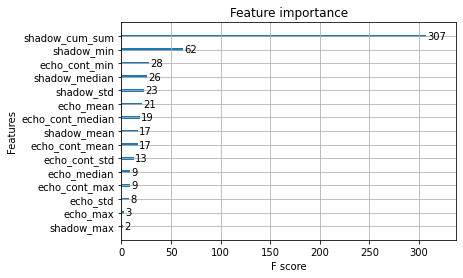

```python
plot_importance(xgb_cls)
```

Выберем первые 8 значимых признаков, так ранее мы выбрали тоже 8

```python
feature_choose_sop_2=features_train_sop_2[['shadow_cum_sum', 'shadow_min', 'echo_cont_min', 'shadow_median',
       'shadow_std', 'echo_mean', 'echo_cont_median', 'shadow_mean']]
```

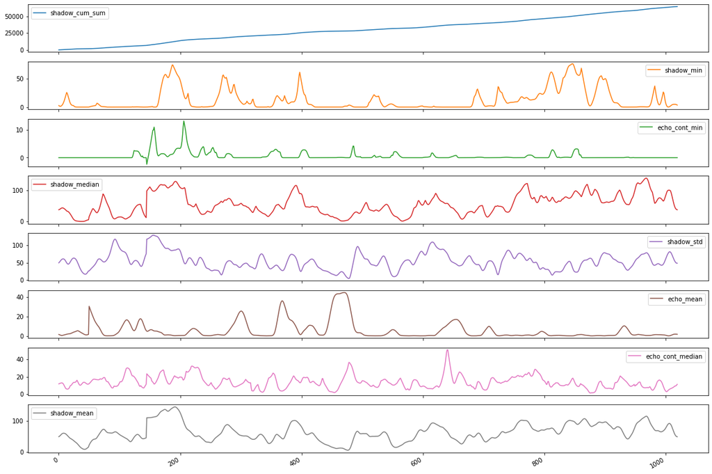

```python
feature_choose_sop_2.plot(subplots=True, figsize=(20,15));
```

#### SOP3

```python
x_train, x_test,y_train, y_test= train_test_split(features_train_sop_3, target_values_sop_3,
                                                  stratify=target_values_sop_3, shuffle=True, random_state=20)
```

```python
xgb_cls= XGBClassifier(n_estimators=100, n_jobs=-1)
```

```python
xgb_cls.fit(x_train, y_train)
```

```
XGBClassifier(base_score=0.5, booster='gbtree', colsample_bylevel=1,
              colsample_bynode=1, colsample_bytree=1, gamma=0,
              learning_rate=0.1, max_delta_step=0, max_depth=3,
              min_child_weight=1, missing=None, n_estimators=100, n_jobs=-1,
              nthread=None, objective='binary:logistic', random_state=0,
              reg_alpha=0, reg_lambda=1, scale_pos_weight=1, seed=None,
              silent=None, subsample=1, verbosity=1)
```

```python
xgb_cls.score(x_test, y_test)
```

```
0.9882352941176471
```

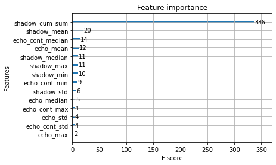

```python
plt.figure(figsize=(10,8))
plot_importance(xgb_cls)
```

Выберем первые 8 значимых признаков, так ранее мы выбрали тоже 8

```python
feature_choose_sop_3=features_train_sop_3[['shadow_cum_sum', 'shadow_mean', 'echo_cont_median', 'echo_mean',
       'shadow_median', 'shadow_max', 'shadow_min', 'echo_cont_min']]
```

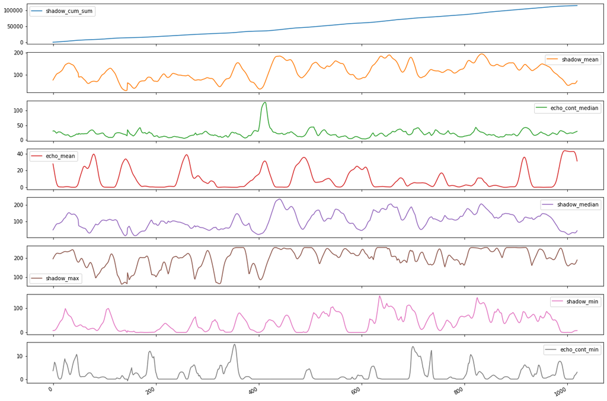

```python
feature_choose_sop_3.plot(subplots=True, figsize=(20,15));
```

## 3.3. АРГУМЕНТИРОВАННЫЙ ВЫБОР АЛГОРИТМА ДЛЯ КЛАСТЕРИЗАЦИИ

```python
from sklearn.preprocessing import MinMaxScaler
scal=MinMaxScaler()
scaling_features_1=scal.fit_transform(feature_choose_sop_1)
```

```python
from sklearn.cluster import KMeans, AffinityPropagation, MeanShift, AgglomerativeClustering
from scipy.cluster.hierarchy import dendrogram, linkage
from sklearn.metrics import accuracy_score, confusion_matrix, classification_report
```

### 3.3.1. В качестве алгоритмов кластеризации будем использовать следующие алгоритмы:

1. Метод к-средних
2. Иерархическая кластеризация
3. MeanShift

#### Метод к-средних

```python
kmeans=KMeans(n_clusters=2, init='k-means++', random_state=10)
```

```python
pred_kmeans=kmeans.fit_predict(scaling_features_1)
```

```python
accuracy_score(pred_kmeans, target_values_sop_1)
```

```
0.4303921568627451
```

```python
print(classification_report(pred_kmeans, target_values_sop_1))
```

```
              precision    recall  f1-score   support

           0       0.40      0.68      0.50       428
           1       0.52      0.25      0.34       592

    accuracy                           0.43      1020
   macro avg       0.46      0.46      0.42      1020
weighted avg       0.47      0.43      0.41      1020
```

Точность алгоритма кластеризации методом к-средних равна 43%

```python
kmeans_2=KMeans(n_clusters=2, init='k-means++', random_state=20)
pred_sop_2=kmeans_2.fit_predict(scaling_features_2)
```

```python
accuracy_score(pred_sop_2, target_values_sop_2)
```

```
0.34901960784313724
```

```python
kmeans_3=KMeans(n_clusters=2, init='k-means++', random_state=30)
pred_sop_3=kmeans_3.fit_predict(scaling_features_3)
```

```python
accuracy_score(pred_sop_3, target_values_sop_3)
```

```
0.5549019607843138
```

#### Иерархическая кластеризация

```python
agl_cl=AgglomerativeClustering(n_clusters=2)
```

```python
agl_pred=agl_cl.fit_predict(scaling_features_1)
```

```python
accuracy_score(agl_pred, target_values_sop_1)
```

```
0.5843137254901961
```

```python
print(classification_report(agl_pred, target_values_sop_1))
```

```
              precision    recall  f1-score   support

           0       0.63      0.75      0.68       607
           1       0.48      0.34      0.40       413

    accuracy                           0.58      1020
   macro avg       0.55      0.54      0.54      1020
weighted avg       0.57      0.58      0.57      1020
```

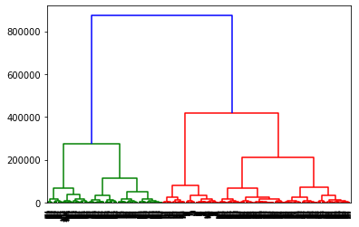

```python
link = linkage(feature_choose_sop_1, 'ward')
dend=dendrogram(link)
```

#### MeanShift

```python
mean_shift=MeanShift(n_jobs=-1)
```

```python
pred_mean_shift=mean_shift.fit_predict(scaling_features_1)
```

```python
accuracy_score(pred_mean_shift, target_values_sop_1)
```

```
0.7166666666666667
```

```python
print(classification_report(pred_mean_shift, target_values_sop_1))
```

```
              precision    recall  f1-score   support

           0       1.00      0.72      0.83      1020
           1       0.00      0.00      0.00         0

    accuracy                           0.72      1020
   macro avg       0.50      0.36      0.42      1020
weighted avg       1.00      0.72      0.83      1020
```

Точность алгоритма MeanShift равна 72%

#### Визуализация методов кластеризации

```python
from sklearn.decomposition import PCA
```

SOP1

```python
pca=PCA()
```

```python
pca_feat=pca.fit_transform(scaling_features_1)
```

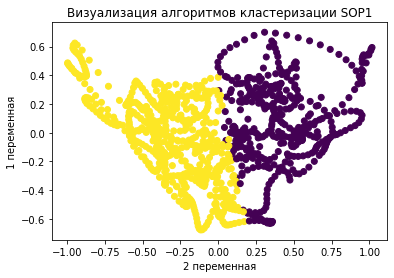

```python
plt.scatter(pca_feat[:,0], pca_feat[:,1], c=pred_kmeans)
plt.title("Визуализация алгоритмов кластеризации SOP1")
plt.xlabel("2 переменная")
plt.ylabel("1 переменная")
```

SOP2

```python
scal=MinMaxScaler()
scaling_features_2=scal.fit_transform(feature_choose_sop_2)
```

```python
scaling_features_3=scal.fit_transform(feature_choose_sop_3)
```

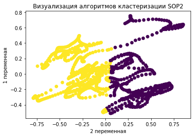

```python
pca=PCA()
pca_feat_2=pca.fit_transform(scaling_features_2)
plt.scatter(pca_feat_2[:,0], pca_feat_2[:,1], c=pred_sop_2)
plt.title("Визуализация алгоритмов кластеризации SOP2")
plt.xlabel("2 переменная")
plt.ylabel("1 переменная")
```

SOP3

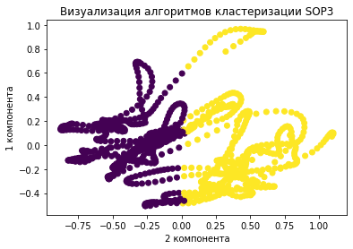

```python
pca=PCA()
pca_feat_3=pca.fit_transform(scaling_features_3)
plt.scatter(pca_feat_3[:,0], pca_feat_3[:,1], c=pred_sop_3)
plt.title("Визуализация алгоритмов кластеризации SOP3")
plt.xlabel("2 компонента")
plt.ylabel("1 компонента")
```

## 4. РЕЗУЛЬТАТ КЛАСТЕРНОГО АНАЛИЗА

```python
def write_pred(data, name):
    return pd.Series(data).to_csv(name, index=False)
```

```python
write_pred(pred_kmeans, "/content/drive/My Drive/brics2020/predict_sop_1.csv")
```

```python
write_pred(pred_sop_2, "/content/drive/My Drive/brics2020/predict_sop_2.csv")
```

```python
write_pred(pred_sop_3, "/content/drive/My Drive/brics2020/predict_sop_3.csv")
```

# Модуль 4

## 4.1. РАЗБИЕНИЕ ДАННЫХ НА ОБУЧАЮЩУЮ И ПРОВЕРОЧНУЮ ВЫБОРКУ

### Загрузка данных

> Загружаем только:
> 1. k3.dat
> 2. k16.dat
> 3. k22.dat
> 4. k24.dat
> 5. k28.dat

> Так как в целевых переменных есть только:
> 1. k3.csv
> 2. k16.csv
> 3. k22.csv
> 4. k24.csv
> 5. k28.csv

#### Загрузка результатов контроля

```python
k3 = []
k3 = pd.read_csv('/content/drive/My Drive/brics2020/Results/К3.dat', sep=' ', skiprows=1, engine='python',header=None)
k3 = k3.iloc[:,1:]
```

```python
k16 = []
k16 = pd.read_csv('/content/drive/My Drive/brics2020/Results/К16.dat', sep=' ', skiprows=1, engine='python',header=None)
k16 = k16.iloc[:,1:]
```

```python
k22 = []
k22 = pd.read_csv('/content/drive/My Drive/brics2020/Results/К22.dat', sep=' ', skiprows=1, engine='python',header=None)
k22 = k22.iloc[:,1:]
```

```python
k24 = []
k24 = pd.read_csv('/content/drive/My Drive/brics2020/Results/К24.dat', sep=' ', skiprows=1, engine='python',header=None)
k24 = k24.iloc[:,1:]
```

```python
k28 = []
k28 = pd.read_csv('/content/drive/My Drive/brics2020/Results/К28.dat', sep=' ', skiprows=1, engine='python',header=None)
k28 = k28.iloc[:,1:]
```

#### Загрузка целевых переменных

```python
t3 = pd.read_csv('/content/drive/My Drive/brics2020/Target/k3.csv', sep='	')
```

```python
t16 = pd.read_csv('/content/drive/My Drive/brics2020/Target/k16.csv', sep='	')
```

```python
t22 = pd.read_csv('/content/drive/My Drive/brics2020/Target/k22.csv', sep='	')
```

```python
t24 = pd.read_csv('/content/drive/My Drive/brics2020/Target/k24.csv', sep='	')
```

```python
t28 = pd.read_csv('/content/drive/My Drive/brics2020/Target/k28.csv', sep='	')
```

### Подготовка данных

```python
from statsmodels.nonparametric.smoothers_lowess import lowess
```

#### Функция сглаживания

```python
def smoothclipp(data):
    time_data=range(0,len(data))
    data_smooth=pd.DataFrame(data)
    for ind,col in enumerate(data.columns):
        filtered=lowess(data[col], time_data, it=0, frac=0.02, is_sorted=True)
        data_smooth[col]=filtered[:,1]
    return data_smooth
```

```python
k3_prep = smoothclipp(k3)
```

```python
k16_prep = smoothclipp(k16)
```

```python
k22_prep = smoothclipp(k22)
```

```python
k24_prep = smoothclipp(k24)
```

```python
k28_prep = smoothclipp(k28)
```

#### Выделим признаки хордового и Р-С

```python
hord = [1, 2, 7, 8, 11, 12, 13, 14, 15, 16]
rs=[3, 4, 5, 6, 9, 10]
```

##### Функция сдвига

```python
def shift_value(data):
    data_shift=pd.DataFrame()
    for col in data[hord].columns:
        data_shift[col]=np.roll(data[col], shift=145)
    for col in data[rs].columns:
        data_shift[col]=np.roll(data[col], shift=50)
    data_shift = data_shift.iloc[:1020, :]
    return data_shift
```

```python
k3_shift=shift_value(k3_prep)
```

```python
k16_shift=shift_value(k16_prep)
```

```python
k22_shift=shift_value(k22_prep)
```

```python
k24_shift=shift_value(k24_prep)
```

```python
k28_shift=shift_value(k28_prep)
```

##### Выделим признаки теневого и эхо-контактного метода

```python
echo = [1, 2, 3, 4, 7, 8]
shadow = [5, 6, 13, 14]
echo_cont = [9, 10, 11, 12, 15, 16]
```

##### Функция для получения переменных

```python
def stats_add_to_data(data, new_data, name):
    new_data[name + "mean"] = data.mean(axis=1)
    new_data[name + "median"] = data.median(axis=1)
    new_data[name + "cum_sum"] = data.mean(axis=1).cumsum()
    new_data[name + "std"] = data.std(axis=1)
    new_data[name + "min"] = data.min(axis=1)
    new_data[name + "max"] = data.max(axis=1)
```

```python
def featchoos(data_shift):
    features_train = pd.DataFrame()
    data_shift = data_shift.T
    shadow_features = data_shift.loc[shadow].T
    echo_features = data_shift.loc[echo].T
    echo_cont_features = data_shift.loc[echo_cont].T
    stats_add_to_data(shadow_features, features_train, "shadow_")
    stats_add_to_data(echo_features, features_train, "echo_")
    stats_add_to_data(echo_cont_features, features_train, "echo_сont_")
    return features_train
```

```python
fk3 = featchoos(k3_shift)
```

```python
fk16 = featchoos(k16_shift)
```

```python
fk22 = featchoos(k22_shift)
```

```python
fk24 = featchoos(k24_shift)
```

```python
fk28 = featchoos(k28_shift)
```

```python
def columnss_target(target):
    target.columns=["start", "len", "height", "type", "side"]
```

```python
def replace_target(target):
    target["type"]=target["type"].replace({"L": 1, "T": 0})
    target["side"]=target["side"].replace({"A": 1, "B": 0 })
```

```python
columnss_target(t3)
columnss_target(t16)
columnss_target(t22)
columnss_target(t24)
columnss_target(t28)
```

```python
replace_target(t3)
```

```python
replace_target(t16)
```

```python
replace_target(t22)
```

```python
replace_target(t24)
```

```python
replace_target(t28)
```

Формирование векторов целевой переменной

T3

```python
t3
```

|  | start | len | height | type | side |
| --- | --- | --- | --- | --- | --- |
| 0 | 43 | 33.0 | 4 | 1 | 0 |
| 1 | 191 | 53.0 | 4 | 1 | 1 |
| 2 | 780 | 89.0 | 8 | 1 | 0 |
| 3 | 654 | NaN | 4 | 0 |  |

```python
tv3_length=pd.DataFrame(index=fk3.index)
tv3_length["len"]=0
tv3_length["len"][43:43+33]=33
tv3_length["len"][191:191+53]=53
tv3_length["len"][780:780+89]=89
tv3_length["len"][654:654]=0
```

```python
tv3_type=pd.DataFrame(index=fk3.index)
tv3_type["type"]=0
tv3_type["type"][43:43+33]=1
tv3_type["type"][191:191+53]=1
tv3_type["type"][780:780+89]=1
tv3_type["type"][654:654]=0
```

```python
tv3_start=pd.DataFrame(index=fk3.index)
tv3_start["start"]=0
tv3_start["start"][43:43+33]=43
tv3_start["start"][191:191+53]=191
tv3_start["start"][780:780+89]=780
tv3_start["start"][654:654]=654
```

```python
tv3_height=pd.DataFrame(index=fk3.index)
tv3_height["height"]=0
tv3_height["height"][43:43+33]=4
tv3_height["height"][191:191+53]=4
tv3_height["height"][780:780+89]=8
tv3_height["height"][654:654]=4
```

```python
tv3_height=pd.DataFrame(index=fk3.index)
tv3_height["type"]=0
tv3_height["type"][43:43+33]=1
tv3_height["type"][191:191+53]=1
tv3_height["type"][780:780+89]=1
tv3_height["type"][654:654]=0
```

```python
tv3_side=pd.DataFrame(index=fk3.index)
tv3_side["side"]=0
tv3_side["side"][43:43+33]=0
tv3_side["side"][191:191+53]=1
tv3_side["side"][780:780+89]=0
tv3_side["side"][654:654]=0
```

```python
tv3_target=pd.DataFrame(index=fk3.index)
tv3_target["target"]=0
tv3_target["target"][43:43+33]=1
tv3_target["target"][191:191+53]=1
tv3_target["target"][780:780+89]=1
tv3_target["target"][654:654]=1
```

T16

```python
t16
```

|  | start | len | height | type | side |
| --- | --- | --- | --- | --- | --- |
| 0 | 456 | 123.0 | 6 | 1 | 1 |
| 1 | 598 | 18.0 | 4 | 1 | 0 |
| 2 | 670 | NaN | 5 | 0 |  |

```python
tv16_length=pd.DataFrame(index=fk16.index)
tv16_length["len"]=0
tv16_length["len"][456:456+123]=123
tv16_length["len"][598:598+18]=18
tv16_length["len"][670:670]=0
tv16_start=pd.DataFrame(index=fk16.index)
tv16_start["start"]=0
tv16_start["start"][456:456+123]=456
tv16_start["start"][598:598+18]=598
tv16_start["start"][670:670]=670
tv16_height=pd.DataFrame(index=fk16.index)
tv16_height["height"]=0
tv16_height["height"][456:456+123]=6
tv16_height["height"][598:598+18]=4
tv16_height["height"][670:670]=5
tv16_type=pd.DataFrame(index=fk16.index)
tv16_type["type"]=3
tv16_type["type"][456:456+123]=1
tv16_type["type"][598:598+18]=1
tv16_type["type"][670:670]=0
tv16_side=pd.DataFrame(index=fk16.index)
tv16_side["side"]=3
tv16_side["side"][456:456+123]=1
tv16_side["side"][598:598+18]=0
tv16_side["side"][670:670]=0
tv16_target=pd.DataFrame(index=fk16.index)
tv16_target["target"]=0
tv16_target["target"][456:456+123]=1
tv16_target["target"][598:598+18]=1
tv16_target["target"][670:670]=1
```

```python
t22
```

|  | start | len | height | type | side |
| --- | --- | --- | --- | --- | --- |
| 0 | 581 | 91.0 | 7 | 1 | 0 |
| 1 | 388 | NaN | 2 | 0 |  |

```python
tv22_length=pd.DataFrame(index=fk22.index)
tv22_length["len"]=0
tv22_length["len"][581:581+91]=91
tv22_length["len"][388:388]=0
tv22_start=pd.DataFrame(index=fk22.index)
tv22_start["start"]=0
tv22_start["start"][581:581+91]=581
tv22_start["start"][388:388]=388
tv22_height=pd.DataFrame(index=fk22.index)
tv22_height["height"]=0
tv22_height["height"][581:581+91]=7
tv22_height["height"][388:388]=2
tv22_type=pd.DataFrame(index=fk22.index)
tv22_type["type"]=3
tv22_type["type"][581:581+91]=1
tv22_type["type"][388:388]=3
tv22_side=pd.DataFrame(index=fk22.index)
tv22_side["side"]=3
tv22_side["side"][581:581+91]=0
tv22_side["side"][388:388]=0
tv22_target=pd.DataFrame(index=fk22.index)
tv22_target["target"]=0
tv22_target["target"][581:581+91]=1
tv22_target["target"][388:388]=1
```

```python
t24
```

|  | start | len | height | type | side |
| --- | --- | --- | --- | --- | --- |
| 0 | 251 | 17.0 | 8 | 1 | 1 |
| 1 | 583 | 128.0 | 7 | 1 | 0 |
| 2 | 475 | NaN | 3 | 0 |  |

```python
tv24_length=pd.DataFrame(index=fk24.index)
tv24_length["len"]=0
tv24_length["len"][251:251+17]=17
tv24_length["len"][583:583+128]=128
tv24_length["len"][475:475]=0
tv24_start=pd.DataFrame(index=fk24.index)
tv24_start["start"]=0
tv24_start["start"][251:251+17]=251
tv24_start["start"][583:583+128]=583
tv24_start["start"][475:475]=475
tv24_height=pd.DataFrame(index=fk24.index)
tv24_height["height"]=0
tv24_height["height"][251:251+17]=8
tv24_height["height"][583:583+128]=7
tv24_height["height"][475:475]=3
tv24_type=pd.DataFrame(index=fk24.index)
tv24_type["type"]=3
tv24_type["type"][251:251+17]=1
tv24_type["type"][583:583+128]=1
tv24_type["type"][475:475]=0
tv24_side=pd.DataFrame(index=fk24.index)
tv24_side["side"]=3
tv24_side["side"][251:251+17]=1
tv24_side["side"][583:583+128]=0
tv24_side["side"][475:475]=0
tv24_target=pd.DataFrame(index=fk24.index)
tv24_target["target"]=0
tv24_target["target"][251:251+17]=1
tv24_target["target"][583:583+128]=1
tv24_target["target"][475:475]=1
```

```python
t28
```

|  | start | len | height | type | side |
| --- | --- | --- | --- | --- | --- |
| 0 | 67 | 52.0 | 5 | 1 | 0 |
| 1 | 838 | 114.0 | 7 | 1 | 1 |
| 2 | 382 | NaN | 4 | 0 |  |
| 3 | 891 | NaN | 4 | 0 |  |
| 4 | 948 | NaN | 5 | 0 |  |

```python
tv28_length=pd.DataFrame(index=fk28.index)
tv28_length["len"]=0
tv28_length["len"][67:67+52]=52
tv28_length["len"][838:838+114]=114
tv28_length["len"][382:382]=0
tv28_length["len"][891:891]=0
tv28_length["len"][948:948]=0
tv28_start=pd.DataFrame(index=fk28.index)
tv28_start["start"]=0
tv28_start["start"][67:67+52]=67
tv28_start["start"][838:838+114]=838
tv28_start["start"][382:382]=382
tv28_start["start"][891:891]=891
tv28_start["start"][948:948]=948
tv28_height=pd.DataFrame(index=fk28.index)
tv28_height["height"]=0
tv28_height["height"][67:67+52]=5
tv28_height["height"][838:838+114]=7
tv28_height["height"][382:382]=4
tv28_height["height"][891:891]=4
tv28_height["height"][948:948]=5
tv28_type=pd.DataFrame(index=fk28.index)
tv28_type["type"]=0
tv28_type["type"][67:67+52]=1
tv28_type["type"][838:838+114]=1
tv28_type["type"][382:382]=0
tv28_type["type"][891:891]=0
tv28_type["type"][948:948]=0
tv28_side=pd.DataFrame(index=fk28.index)
tv28_side["side"]=0
tv28_side["side"][67:67+52]=0
tv28_side["side"][838:838+114]=1
tv28_side["side"][382:382]=0
tv28_side["side"][891:891]=0
tv28_side["side"][948:948]=0
tv28_target=pd.DataFrame(index=fk28.index)
tv28_target["target"]=0
tv28_target["target"][67:67+52]=1
tv28_target["target"][838:838+114]=1
tv28_target["target"][382:382]=1
tv28_target["target"][891:891]=1
tv28_target["target"][948:948]=1
```

```python
df_train=pd.concat([fk3, fk28])
df_test=pd.concat([fk16, fk22, fk24])
```

Тренировочные выборки

```python
target_len_train=pd.concat([tv3_length, tv28_length])
target_start_train=pd.concat([tv3_start, tv28_start])
target_height_train=pd.concat([tv3_height, tv28_height])
target_side_train=pd.concat([tv3_side, tv28_side])
target_type_train=pd.concat([tv3_type, tv28_type])
target_target_train=pd.concat([tv3_target, tv28_target])
```

Тестовые выборки

```python
target_len_test=pd.concat([tv16_length, tv22_length, tv24_length])
target_start_test=pd.concat([tv16_start, tv22_start, tv24_start])
target_height_test=pd.concat([tv16_height, tv22_height, tv24_height])
target_side_test=pd.concat([tv16_side, tv22_side, tv24_side])
target_type_test=pd.concat([tv16_type, tv22_type, tv24_type])
target_target_test=pd.concat([tv16_target, tv22_target, tv24_target])
```

## 4.2 ВИЗУАЛЬНОЕ ОБОСНОВАНИЕ ВЫБОРА ПЕРЕМЕННЫХ/ РАБОТОСПОСОБНОСТИ МОДЕЛИ

XGBoost

```python
from xgboost import XGBClassifier
from sklearn.model_selection import train_test_split
from xgboost import plot_importance
from sklearn.metrics import confusion_matrix, roc_auc_score
```

Предсказание длины дефекта

```python
x_train_len, x_test_len,y_train_len, y_test_len= train_test_split(df_train, target_len_train,
                                                  stratify=target_len_train, shuffle=True, random_state=20)
```

Определение длины дефекта

```python
xgb_cls_len= XGBClassifier(n_estimators=100, n_jobs=-1)
xgb_cls_len.fit(x_train_len, y_train_len)
```

```
XGBClassifier(base_score=0.5, booster='gbtree', colsample_bylevel=1,
              colsample_bynode=1, colsample_bytree=1, gamma=0,
              learning_rate=0.1, max_delta_step=0, max_depth=3,
              min_child_weight=1, missing=None, n_estimators=100, n_jobs=-1,
              nthread=None, objective='multi:softprob', random_state=0,
              reg_alpha=0, reg_lambda=1, scale_pos_weight=1, seed=None,
              silent=None, subsample=1, verbosity=1)
```

Точность алгоритма

```python
xgb_cls_len.score(x_test_len, y_test_len)
```

```
0.9941176470588236
```

Влияние переменных

```python
plot_importance(xgb_cls_len)
```

[output not shown]

Матрица ошибок

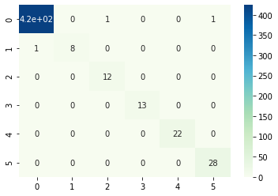

```python
sns.heatmap(confusion_matrix(xgb_cls_len.predict(x_test_len), y_test_len), annot=True, cmap='GnBu')
```

Определение наличия дефекта

```python
x_train_target, x_test_target,y_train_target, y_test_target= train_test_split(df_train, target_target_train,
                                                  stratify=target_target_train, shuffle=True, random_state=20)
```

```python
xgb_cls_target= XGBClassifier(n_estimators=100, n_jobs=-1)
xgb_cls_target.fit(x_train_target, y_train_target)
```

```
XGBClassifier(base_score=0.5, booster='gbtree', colsample_bylevel=1,
              colsample_bynode=1, colsample_bytree=1, gamma=0,
              learning_rate=0.1, max_delta_step=0, max_depth=3,
              min_child_weight=1, missing=None, n_estimators=100, n_jobs=-1,
              nthread=None, objective='binary:logistic', random_state=0,
              reg_alpha=0, reg_lambda=1, scale_pos_weight=1, seed=None,
              silent=None, subsample=1, verbosity=1)
```

Точность алгоритма

```python
xgb_cls_target.score(x_test_target, y_test_target)
```

```
0.9980392156862745
```

Влияние переменных

```python
plot_importance(xgb_cls_len)
```

[output not shown]

Матрица ошибок

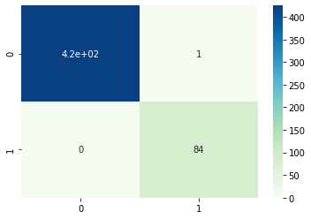

```python
sns.heatmap(confusion_matrix(xgb_cls_target.predict(x_test_target), y_test_target), annot=True, cmap='GnBu')
```

Определение высоты дефекта

```python
x_train_height, x_test_height, y_train_height, y_test_height = train_test_split(df_train, target_height_train,
                                                  stratify=target_height_train, shuffle=True, random_state=20)
```

```python
xgb_cls_height= XGBClassifier(n_estimators=100, n_jobs=-1)
xgb_cls_height.fit(x_train_len, y_train_len)
```

```
XGBClassifier(base_score=0.5, booster='gbtree', colsample_bylevel=1,
              colsample_bynode=1, colsample_bytree=1, gamma=0,
              learning_rate=0.1, max_delta_step=0, max_depth=3,
              min_child_weight=1, missing=None, n_estimators=100, n_jobs=-1,
              nthread=None, objective='multi:softprob', random_state=0,
              reg_alpha=0, reg_lambda=1, scale_pos_weight=1, seed=None,
              silent=None, subsample=1, verbosity=1)
```

Точность алгоритма

```python
xgb_cls_len.score(x_test_height, y_test_height)
```

```
0.8313725490196079
```

Влияние переменных

```python
plot_importance(xgb_cls_height)
```

[output not shown]

Матрица ошибок

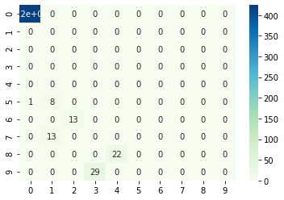

```python
sns.heatmap(confusion_matrix(xgb_cls_height.predict(x_test_height), y_test_height), annot=True, cmap='GnBu')
```

Определение начала дефекта

```python
x_train_start, x_test_start, y_train_start, y_test_start = train_test_split(df_train, target_start_train,
                                                  stratify=target_start_train, shuffle=True, random_state=20)
```

```python
xgb_cls_start= XGBClassifier(n_estimators=100, n_jobs=-1)
xgb_cls_start.fit(x_train_start, y_train_start)
```

```
XGBClassifier(base_score=0.5, booster='gbtree', colsample_bylevel=1,
              colsample_bynode=1, colsample_bytree=1, gamma=0,
              learning_rate=0.1, max_delta_step=0, max_depth=3,
              min_child_weight=1, missing=None, n_estimators=100, n_jobs=-1,
              nthread=None, objective='multi:softprob', random_state=0,
              reg_alpha=0, reg_lambda=1, scale_pos_weight=1, seed=None,
              silent=None, subsample=1, verbosity=1)
```

Точность алгоритма

```python
xgb_cls_start.score(x_test_start, y_test_start)
```

```
0.996078431372549
```

Влияние переменных

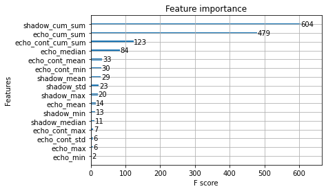

```python
plot_importance(xgb_cls_start)
```

Матрица ошибок

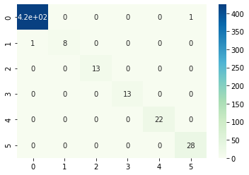

```python
sns.heatmap(confusion_matrix(xgb_cls_start.predict(x_test_start), y_test_start), annot=True, cmap='GnBu')
```

Определение типа дефекта

```python
x_train_type, x_test_type, y_train_type, y_test_type = train_test_split(df_train, target_type_train,
                                                  stratify=target_type_train, shuffle=True, random_state=20)
```

```python
xgb_cls_type= XGBClassifier(n_estimators=100, n_jobs=-1)
xgb_cls_type.fit(x_train_type, y_train_type)
```

```
XGBClassifier(base_score=0.5, booster='gbtree', colsample_bylevel=1,
              colsample_bynode=1, colsample_bytree=1, gamma=0,
              learning_rate=0.1, max_delta_step=0, max_depth=3,
              min_child_weight=1, missing=None, n_estimators=100, n_jobs=-1,
              nthread=None, objective='binary:logistic', random_state=0,
              reg_alpha=0, reg_lambda=1, scale_pos_weight=1, seed=None,
              silent=None, subsample=1, verbosity=1)
```

Точность алгоритма

```python
xgb_cls_start.score(x_test_type, y_test_type)
```

```
0.8313725490196079
```

Влияние переменных

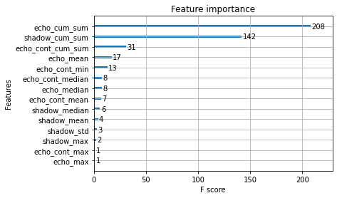

```python
plot_importance(xgb_cls_type)
```

Матрица ошибок

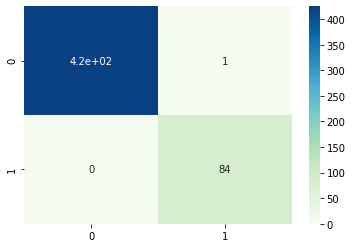

```python
sns.heatmap(confusion_matrix(xgb_cls_type.predict(x_test_type), y_test_type), annot=True, cmap='GnBu')
```

Определение стороны дефекта

```python
x_train_side, x_test_side, y_train_side, y_test_side = train_test_split(df_train.dropna(), target_side_train,
                                                  stratify=target_side_train, shuffle=True, random_state=20)
```

```python
xgb_cls_side= XGBClassifier(n_estimators=100, n_jobs=-1)
xgb_cls_side.fit(x_train_side, y_train_side)
```

```
XGBClassifier(base_score=0.5, booster='gbtree', colsample_bylevel=1,
              colsample_bynode=1, colsample_bytree=1, gamma=0,
              learning_rate=0.1, max_delta_step=0, max_depth=3,
              min_child_weight=1, missing=None, n_estimators=100, n_jobs=-1,
              nthread=None, objective='binary:logistic', random_state=0,
              reg_alpha=0, reg_lambda=1, scale_pos_weight=1, seed=None,
              silent=None, subsample=1, verbosity=1)
```

Точность алгоритма

```python
xgb_cls_start.score(x_test_side, y_test_side)
```

```
0.8254901960784313
```

Влияние переменных

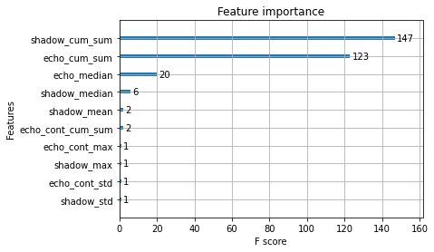

```python
plot_importance(xgb_cls_side)
```

Матрица ошибок

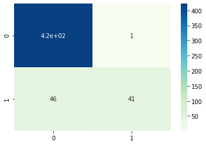

```python
sns.heatmap(confusion_matrix(xgb_cls_type.predict(x_test_side), y_test_side), annot=True, cmap='GnBu')
```